# Documento de resultados

Daniel Miranda, Juan Carlos Castillo, Catalina Miranda & José Conejeros

Marzo, 2020

# Data

```r
#rm(list = ls())
#Cargamos base de datos
load("C:/Users/DM/Dropbox (Personal)/book_authoritarianism/Data/Analisis/ICCS09.Rdata")
load("C:/Users/DM/Dropbox (Personal)/book_authoritarianism/Data/Analisis/ICCS16.Rdata")
```

# Variables

```r
#Data frames with all variables
#2009
dict09 =  iccs09 %>%
  mutate(time          = 2009) %>%
  mutate(country       = COUNTRY) %>%
  mutate(idcountry     = IDCNTRY) %>%
  mutate(idschool       = IDSCHOOL) %>%
  mutate(idstudent     = IDSTUD) %>%
  mutate(idstudent = (time*1000000000000 + idcountry*100000000 + idstudent)) %>% #NEW IDSTUDENT
  #Authoritarianism
  mutate(dicta1         = 5-LS2P02A) %>% #Government leaders to make decisions without consulting anybody
  mutate(dicta2         = 5-LS2P02B) %>% #People in government must enforce their authority even
  mutate(dicta3         = 5-LS2P02C) %>% #People in government lose part of their authority
  mutate(dicta4         = 5-LS2P02D) %>% #People whose opinions are different must be considered its enemies
  mutate(dicta5         = 5-LS2P02E) %>% #The most important opinion of a country should be that of the pres
  mutate(dicta6         = 5-LS2P02F) %>% #It is fair that the government does not comply with the law
  mutate(dicta7         = 5-LS2P03A) %>% #It is fair that the government does not comply with the law
  mutate(dicta8         = 5-LS2P03B) %>% #Concentration of power in one person guarantees order
  mutate(dicta9         = 5-LS2P03C) %>% #If the president does not agree withCongress>, he should dissolve
  mutate(dicta_safety   = 5-LS2P03D) %>% #DICTATORSHIPS ARE JUSTIFIED WHEN THEY BRING ORDER AND SAFETY
  mutate(dicta_benefits = 5-LS2P03E) %>% #DICTATORSHIPS ARE JUSTIFIED WHEN THEY BRING ECONOMIC BENEFITS
  mutate(dict          = (dicta_safety + dicta_benefits)/2) %>% #MEAN DIC
  #Dummies
  mutate(dicta1_d      = recode(dicta1, "1"=0, "2"=0, "3"=1, "4"=1)) %>%
  mutate(dicta2_d      = recode(dicta2, "1"=0, "2"=0, "3"=1, "4"=1)) %>%
  mutate(dicta3_d      = recode(dicta3, "1"=0, "2"=0, "3"=1, "4"=1)) %>%
  mutate(dicta4_d      = recode(dicta4, "1"=0, "2"=0, "3"=1, "4"=1)) %>%
  mutate(dicta5_d      = recode(dicta5, "1"=0, "2"=0, "3"=1, "4"=1)) %>%
  mutate(dicta6_d      = recode(dicta6, "1"=0, "2"=0, "3"=1, "4"=1)) %>%
  mutate(dicta7_d      = recode(dicta7, "1"=0, "2"=0, "3"=1, "4"=1)) %>%
  mutate(dicta8_d      = recode(dicta8, "1"=0, "2"=0, "3"=1, "4"=1)) %>%
  mutate(dicta9_d      = recode(dicta9, "1"=0, "2"=0, "3"=1, "4"=1)) %>%
  mutate(dicta_saf_d  = recode(dicta_safety, "1"=0, "2"=0, "3"=1, "4"=1)) %>%
  mutate(dicta_ben_d  = recode(dicta_benefits, "1"=0, "2"=0, "3"=1, "4"=1)) %>%
  #Civic Knowledge
  mutate(pv1civ        = PV1CIV) %>%
  mutate(pv2civ        = PV2CIV) %>%
  mutate(pv3civ        = PV3CIV) %>%
  mutate(pv4civ        = PV4CIV) %>%
  mutate(pv5civ        = PV5CIV) %>%
  mutate(civic_knowledge = (pv1civ + pv2civ + pv3civ + pv4civ + pv5civ)/5) %>% #MEAN CIVIC KNOWLEDGE
  #Independent Variables
  mutate(s_opdisc        = OPDISC) %>%  #OPENNESS IN CLASS DISCUSSION
  mutate(s_hisced        = HISCED) %>%  #HIGHEST PARENTAL EDUCATIONAL LEVEL
  mutate(univ            = ifelse(s_hisced>3, 1, 0)) %>% #UNIVERSITARY PARENTS
  mutate(s_hisei         = HISEI) %>%   #PARENT'S HIGHEST OCCUPATIONAL STATUS
  mutate(s_homelit       = HOMELIT) %>% #HOME LITERACY
  mutate(s_gender        = SGENDER) %>% #GENDER OF STUDENT
  mutate(s_age           = SAGE) %>%    #AGE STUDENT
  mutate(s_citcon        = CITCON) %>%  #CONVENTIONAL CITIZENSHIP
  mutate(s_citsoc        = CITSOC) %>%  #SOCIAL MOVEMENT REL. CITIZENSHIP
  mutate(s_citeff        = CITEFF) %>%  #CITIZENSHIP SELF-EFFICACY
  mutate(s_cntatt        = ATTCNT) %>%  #ATTITUDES TOWARDS OWN COUNTRY
  mutate(s_geneql        = GENEQL) %>%  #ATTITUDES TOWARDS GENDER EQUALITY
  mutate(s_ethrght       = ETHRGHT) %>% #EQUAL RIGHTS FOR ALL ETHNIC GROUPS
  mutate(l_attviol       = ATTVIOL) %>% #ATTITUDES: USE OF VIOLENCE
  mutate(l_attdiv        = ATTDIFF) %>% #ATTITUDES: NEIGHBOURHOOD DIVERSITY
  mutate(l_autgov        = AUTGOV) %>%  #AUTHORITARIANISM IN GOVERNMENT
  mutate(l_attcorr       = ATTCORR) %>% #CORRUPT PRACTICES IN GOVERNMENT
  mutate(l_dislaw        = DISLAW) %>%  #ATTITUDES: DISOBEYING THE LAW
  mutate(l_empclas       = EMPATH) %>%  #EMPATHY TOWARDS CLASSMATES
  mutate(s_poldisc       = POLDISC) %>% #DISCUSSION OF POL. AND SOC. ISSUES
  #TRUST
  mutate(s_intrust       = INTRUST) %>% #TRUST IN CIVIC INSTITUTIONS
  mutate(nac_gob       = 5 - IS2P27A) %>% #TRUST INSTITUTIONS-NATIONAL GOVERNMENT
  mutate(local_gob     = 5 - IS2P27B) %>% #TRUST INSTITUTIONS-LOCAL GOVERNMENT
  mutate(courts        = 5 - IS2P27C) %>% #TRUST INSTITUTIONS-COURTS
  mutate(police        = 5 - IS2P27D) %>% #TRUST INSTITUTIONS-POLICE
  mutate(pol_parties   = 5 - IS2P27E) %>% #TRUST INSTITUTIONS-POLITICAL PARTIES
  mutate(parliament    = 5 - IS2P27F) %>% #TRUST INSTITUTIONS-PARLIAMENT
  mutate(media         = 5 - IS2P27G) %>% #TRUST INSTITUTIONS-MEDIA
  mutate(ffaa          = 5 - IS2P27H) %>% #TRUST INSTITUTIONS-FFAA
  mutate(school        = 5 - IS2P27I) %>% #TRUST INSTITUTIONS-SCHOOL
  mutate(unit_nations  = 5 - IS2P27J) %>% #TRUST INSTITUTIONS-UNITED NATIONS
  mutate(people        = 5 - IS2P27K) %>% #TRUST INSTITUTIONS-PEOPLE
  mutate(social          = NA) %>%   #TRUST INSTITUTIONS-SOCIAL MEDIA
  #Dummies
  mutate(nac_gob_d         = recode(nac_gob, "1"=0, "2"=0, "3"=1, "4"=1)) %>%
  mutate(local_gob_d       = recode(local_gob, "1"=0, "2"=0, "3"=1, "4"=1)) %>%
  mutate(courts_d          = recode(courts, "1"=0, "2"=0, "3"=1, "4"=1)) %>%
  mutate(police_d          = recode(police, "1"=0, "2"=0, "3"=1, "4"=1)) %>%
  mutate(pol_parties_d     = recode(pol_parties, "1"=0, "2"=0, "3"=1, "4"=1)) %>%
  mutate(parliament_d      = recode(parliament, "1"=0, "2"=0, "3"=1, "4"=1)) %>%
  mutate(media_d           = recode(media, "1"=0, "2"=0, "3"=1, "4"=1)) %>%
  mutate(ffaa_d            = recode(ffaa, "1"=0, "2"=0, "3"=1, "4"=1)) %>%
  mutate(school_d          = recode(school, "1"=0, "2"=0, "3"=1, "4"=1)) %>%
  mutate(unit_nations_d    = recode(unit_nations, "1"=0, "2"=0, "3"=1, "4"=1)) %>%
  mutate(people_d          = recode(people, "1"=0, "2"=0, "3"=1, "4"=1)) %>%
  mutate(social_d          = NA) %>%
  #WEITHINGS5 -
  mutate(totwgts       = TOTWGTS) %>%   #FINAL STUDENT WEIGHT
  mutate(wgtfac1       = WGTFAC1) %>%   #SCHOOL BASE WEIGHT
  mutate(wgtadj1s      = WGTADJ1S) %>%  #SCHOOL WEIGHT ADJUSTMENT-STUDENT STUDY
  mutate(wgtfac2s      = WGTFAC2S) %>%  #CLASS WEIGHT FACTOR
  mutate(wgtadj2s      = WGTADJ2S) %>%  #CLASS WEIGHT ADJUSTMENT
  mutate(wgtadj3s      = WGTADJ3S) %>%  #STUDENT WEIGHT ADJUSTMENT
  mutate(jkzones       = JKZONES) %>%   #JACKKNIFE ZONE - STUDENT STUDY
  mutate(jkreps        = JKREPS)  %>%  #JACKKNIFE REPLICATE CODE
  select(411:497)
```

```r
#2016
dict16 = iccs16 %>%
  mutate(time            = 2016) %>%
  mutate(country         = COUNTRY) %>%
  mutate(idcountry       = IDCNTRY) %>%
  mutate(idschool        = IDSCHOOL) %>%
  mutate(idstudent       = IDSTUD) %>%
  mutate(idstudent       = (time*100000000000 + idcountry*100000000 + idstudent)) %>% #NEW IDSTUDENT
  #Authoritarianism
  mutate(dicta1         = 5-LS3G01A) %>% #Government leaders to make decisions without consulting anybody
  mutate(dicta2         = 5-LS3G01B) %>% #People in government must enforce their authority even
  mutate(dicta3         = 5-LS3G01C) %>% #People in government lose part of their authority
  mutate(dicta4         = 5-LS3G01D) %>% #People whose opinions are different must be considered its enemies
  mutate(dicta5         = 5-LS3G01E) %>% #The most important opinion of a country should be that of the pres
  mutate(dicta6         = 5-LS3G01F) %>% #It is fair that the government does not comply with the law
  mutate(dicta7         = 5-LS3G02A) %>% #It is fair that the government does not comply with the law
  mutate(dicta8         = 5-LS3G02B) %>% #Concentration of power in one person guarantees order
  mutate(dicta9         = 5-LS3G02C) %>% #If the president does not agree withCongress>, he should dissolve
  mutate(dicta_safety    = 5-LS3G02D) %>% #DICTATORSHIPS ARE JUSTIFIED WHEN THEY BRING ORDER AND SAFETY
  mutate(dicta_benefits  = 5-LS3G02E) %>% #DICTATORSHIPS ARE JUSTIFIED WHEN THEY BRING ECONOMIC BENEFITS
  mutate(dict           = (dicta_safety + dicta_benefits)/2) %>%
  #Dummies
  mutate(dicta1_d      = recode(dicta1, "1"=0, "2"=0, "3"=1, "4"=1)) %>%
  mutate(dicta2_d      = recode(dicta2, "1"=0, "2"=0, "3"=1, "4"=1)) %>%
  mutate(dicta3_d      = recode(dicta3, "1"=0, "2"=0, "3"=1, "4"=1)) %>%
  mutate(dicta4_d      = recode(dicta4, "1"=0, "2"=0, "3"=1, "4"=1)) %>%
  mutate(dicta5_d      = recode(dicta5, "1"=0, "2"=0, "3"=1, "4"=1)) %>%
  mutate(dicta6_d      = recode(dicta6, "1"=0, "2"=0, "3"=1, "4"=1)) %>%
  mutate(dicta7_d      = recode(dicta7, "1"=0, "2"=0, "3"=1, "4"=1)) %>%
  mutate(dicta8_d      = recode(dicta8, "1"=0, "2"=0, "3"=1, "4"=1)) %>%
  mutate(dicta9_d      = recode(dicta9, "1"=0, "2"=0, "3"=1, "4"=1)) %>%
  mutate(dicta_saf_d  = recode(dicta_safety, "1"=0, "2"=0, "3"=1, "4"=1)) %>%
  mutate(dicta_ben_d  = recode(dicta_benefits, "1"=0, "2"=0, "3"=1, "4"=1)) %>%
  #Civic Knowledge
  mutate(pv1civ          = PV1CIV) %>%
  mutate(pv2civ          = PV2CIV) %>%
  mutate(pv3civ          = PV3CIV) %>%
  mutate(pv4civ          = PV4CIV) %>%
  mutate(pv5civ          = PV5CIV) %>%
  mutate(civic_knowledge = (pv1civ + pv2civ + pv3civ + pv4civ + pv5civ)/5) %>% #MEAN CIVIC KNOWLEDGE
  #Independent Variables
  mutate(s_opdisc        = S_OPDISC) %>%  #OPENNESS IN CLASS DISCUSSION
  mutate(s_hisced        = S_HISCED) %>%  #HIGHEST PARENTAL EDUCATIONAL LEVEL
  mutate(univ            = ifelse(s_hisced>3, 1, 0)) %>% #UNIVERSITARY PARENTS
  mutate(s_hisei         = S_HISEI) %>%   #PARENT'S HIGHEST OCCUPATIONAL STATUS
  mutate(s_homelit       = S_HOMLIT) %>%  #HOME LITERACY
  mutate(s_gender        = S_GENDER) %>%  #GENDER OF STUDENT
  mutate(s_age           = S_AGE) %>%     #AGE STUDENT
  mutate(s_citcon        = S_CITCON) %>%  #CONVENTIONAL CITIZENSHIP
  mutate(s_citsoc        = S_CITSOC) %>%  #SOCIAL MOVEMENT REL. CITIZENSHIP
  mutate(s_citeff        = S_CITEFF) %>%  #CITIZENSHIP SELF-EFFICACY
  mutate(s_cntatt        = S_CNTATT) %>%  #ATTITUDES TOWARDS OWN COUNTRY
  mutate(s_geneql        = S_GENEQL) %>%  #ATTITUDES TOWARDS GENDER EQUALITY
  mutate(s_ethrght       = S_ETHRGHT) %>% #EQUAL RIGHTS FOR ALL ETHNIC GROUPS
  mutate(l_attviol       = L_ATTVIOL) %>% #ATTITUDES: USE OF VIOLENCE
  mutate(l_attdiv        = L_ATTDIV) %>%  #ATTITUDES: NEIGHBOURHOOD DIVERSITY
  mutate(l_autgov        = L_AUTGOV) %>%  #AUTHORITARIANISM IN GOVERNMENT
  mutate(l_attcorr       = L_ATTCORR) %>% #CORRUPT PRACTICES IN GOVERNMENT
  mutate(l_dislaw        = L_DISLAW) %>%  #ATTITUDES: DISOBEYING THE LAW
  mutate(l_empclas       = L_EMPCLAS) %>% #EMPATHY TOWARDS CLASSMATES
  mutate(s_poldisc       = S_POLDISC) %>% #DISCUSSION OF POL. AND SOC. ISSUES
  #TRUST
  mutate(s_intrust       = S_INTRUST) %>% #TRUST IN CIVIC INSTITUTIONS
  mutate(nac_gob         = 5 - IS3G26A) %>%   #TRUST INSTITUTIONS-NATIONAL GOVERNMENT
  mutate(local_gob       = 5 - IS3G26B) %>%   #TRUST INSTITUTIONS-LOCAL GOVERNMENT
  mutate(courts          = 5 - IS3G26C) %>%   #TRUST INSTITUTIONS-COURTS
  mutate(police          = 5 - IS3G26D) %>%   #TRUST INSTITUTIONS-POLICE
  mutate(pol_parties     = 5 - IS3G26E) %>%   #TRUST INSTITUTIONS-POLITICAL PARTIES
  mutate(parliament      = 5 - IS3G26F) %>%   #TRUST INSTITUTIONS-PARLIAMENT
  mutate(media           = 5 - IS3G26G) %>%   #TRUST INSTITUTIONS-MEDIA
  mutate(ffaa            = 5 - IS3G26I) %>%   #TRUST INSTITUTIONS-FFAA
  mutate(school          = 5 - IS3G26J) %>%   #TRUST INSTITUTIONS-SCHOOL
  mutate(unit_nations    = 5 - IS3G26K) %>%   #TRUST INSTITUTIONS-UNITED NATIONS
  mutate(people          = 5 - IS3G26L) %>%   #TRUST INSTITUTIONS-PEOPLE
  mutate(social          = 5 - IS3G26H) %>%   #TRUST INSTITUTIONS-SOCIAL MEDIA
  #Dummies
  mutate(nac_gob_d         = recode(nac_gob,     "1"=0, "2"=0, "3"=1, "4"=1)) %>%
  mutate(local_gob_d       = recode(local_gob,   "1"=0, "2"=0, "3"=1, "4"=1)) %>%
  mutate(courts_d          = recode(courts,      "1"=0, "2"=0, "3"=1, "4"=1)) %>%
  mutate(police_d          = recode(police,      "1"=0, "2"=0, "3"=1, "4"=1)) %>%
  mutate(pol_parties_d     = recode(pol_parties, "1"=0, "2"=0, "3"=1, "4"=1)) %>%
  mutate(parliament_d      = recode(parliament,  "1"=0, "2"=0, "3"=1, "4"=1)) %>%
  mutate(media_d           = recode(media,       "1"=0, "2"=0, "3"=1, "4"=1)) %>%
  mutate(ffaa_d            = recode(ffaa,        "1"=0, "2"=0, "3"=1, "4"=1)) %>%
  mutate(school_d          = recode(school,      "1"=0, "2"=0, "3"=1, "4"=1)) %>%
  mutate(unit_nations_d    = recode(unit_nations,"1"=0, "2"=0, "3"=1, "4"=1)) %>%
  mutate(people_d          = recode(people,      "1"=0, "2"=0, "3"=1, "4"=1)) %>%
  mutate(social_d          = recode(social,      "1"=0, "2"=0, "3"=1, "4"=1)) %>%
  #WEITHINGS5 -
  mutate(totwgts         = TOTWGTS) %>%   #FINAL STUDENT WEIGHT
  mutate(wgtfac1         = WGTFAC1) %>%   #SCHOOL BASE WEIGHT
  mutate(wgtadj1s        = WGTADJ1S) %>%  #SCHOOL WEIGHT ADJUSTMENT-STUDENT STUDY
  mutate(wgtfac2s        = WGTFAC2S) %>%  #CLASS WEIGHT FACTOR
  mutate(wgtadj2s        = WGTADJ2S) %>%  #CLASS WEIGHT ADJUSTMENT
  mutate(wgtadj3s        = WGTADJ3S) %>%  #STUDENT WEIGHT ADJUSTMENT
  mutate(jkzones         = JKZONES)  %>%  #JACKKNIFE ZONE - STUDENT STUDY
  mutate(jkreps          = JKREPS)  %>%  #JACKKNIFE REPLICATE CODE
  select(519:605)
#Merge data
mergeiccs <- full_join(dict09, dict16)
mergeiccs$ncountry <- countrycode(mergeiccs$country, 'iso3c', 'country.name')
mergeiccs <- mergeiccs[, c(1:3,88,4:87)]
#All observations with complete row data
mergeiccs_miss <- mergeiccs[complete.cases(mergeiccs),]
```

# Sample Size

```r
#ICCS LA: 2009 - 2016
iccs_count <- mergeiccs %>%
  group_by(time, ncountry) %>%
  dplyr::summarise(N=n(), man=mean(s_gender, na.rm=T), age=mean(s_age, na.rm=T)) %>%
  arrange(ncountry)
#ID School
iccs_count2 <- mergeiccs %>%
  group_by(time, ncountry, idschool) %>%
  dplyr::summarise(n=n()) %>%
  dplyr::summarise(s=n()) %>%
  arrange(ncountry)
iccs_count$s <- iccs_count2$s
rm(iccs_count2)
iccs_count$time <- as.character(iccs_count$time)

#Table
#print(xtable(iccs_count[, c(2:1,6,3:5)],  caption = "Sample", format="text"), include.rownames=FALSE)
kable(iccs_count, align = c("lcccccc")) %>%
  kable_styling(bootstrap_options = c("striped", "hover"))
```

| time | ncountry | N | man | age | s |
| --- | --- | --- | --- | --- | --- |
| 2009 | Chile | 5173 | 0.5143801 | 14.17872 | 177 |
| 2016 | Chile | 5081 | 0.4928164 | 14.17268 | 178 |
| 2009 | Colombia | 6200 | 0.5352932 | 14.37904 | 196 |
| 2016 | Colombia | 5609 | 0.5229096 | 14.59167 | 150 |
| 2009 | Dominican Republic | 4569 | 0.5468819 | 14.85543 | 145 |
| 2016 | Dominican Republic | 3937 | 0.5128270 | 14.18576 | 141 |
| 2009 | Guatemala | 3998 | 0.4899699 | 15.51745 | 145 |
| 2009 | Mexico | 6565 | 0.5222493 | 14.08043 | 215 |
| 2016 | Mexico | 5526 | 0.5000000 | 14.03109 | 213 |
| 2009 | Paraguay | 3391 | 0.5213801 | 14.81850 | 149 |
| 2016 | Peru | 5166 | 0.4816105 | 14.03021 | 206 |

# Institutional Trust

```r
#Design
        mergesvy <-  mergeiccs %>%
        as_survey_design(
        strata = jkzones,
        weights = totwgts,
        ids = jkreps,
        nest = TRUE)

#Adjust and table
mergesvy[["variables"]][["nac_gob_d"]] <- as.character(mergesvy[["variables"]][["nac_gob_d"]])
mergesvy[["variables"]][["police_d"]] <- as.character(mergesvy[["variables"]][["police_d"]])
mergesvy[["variables"]][["pol_parties_d"]] <- as.character(mergesvy[["variables"]][["pol_parties_d"]])
mergesvy[["variables"]][["people_d"]] <- as.character(mergesvy[["variables"]][["people_d"]])

#########################
#National Goberment
#########################
table_freq_01 <- mergesvy %>%
        dplyr::group_by(country, time, nac_gob_d) %>%
        summarize(proportion = survey_mean(,na.rm=TRUE, "ci"))
#Table
#print(xtable(table_freq_01,  caption = "Sample", format="text"), include.rownames=FALSE)
kable(table_freq_01, align = c("lcccccc")) %>%
  kable_styling(bootstrap_options = c("striped", "hover"))
```

| country | time | nac_gob_d | proportion | proportion_low | proportion_upp |
| --- | --- | --- | --- | --- | --- |
| CHL | 2009 | 0 | 0.3486123 | 0.3291055 | 0.3681191 |
| CHL | 2009 | 1 | 0.6513877 | 0.6318809 | 0.6708945 |
| CHL | 2016 | 0 | 0.5041627 | 0.4847861 | 0.5235392 |
| CHL | 2016 | 1 | 0.4958373 | 0.4764608 | 0.5152139 |
| COL | 2009 | 0 | 0.3797472 | 0.3552204 | 0.4042741 |
| COL | 2009 | 1 | 0.6202528 | 0.5957259 | 0.6447796 |
| COL | 2016 | 0 | 0.4476026 | 0.4236968 | 0.4715084 |
| COL | 2016 | 1 | 0.5523974 | 0.5284916 | 0.5763032 |
| DOM | 2009 | 0 | 0.2612638 | 0.2365092 | 0.2860184 |
| DOM | 2009 | 1 | 0.7387362 | 0.7139816 | 0.7634908 |
| DOM | 2016 | 0 | 0.2219649 | 0.1992088 | 0.2447210 |
| DOM | 2016 | 1 | 0.7780351 | 0.7552790 | 0.8007912 |
| GTM | 2009 | 0 | 0.5469156 | 0.5200227 | 0.5738086 |
| GTM | 2009 | 1 | 0.4530844 | 0.4261914 | 0.4799773 |
| MEX | 2009 | 0 | 0.4158023 | 0.3954032 | 0.4362014 |
| MEX | 2009 | 1 | 0.5841977 | 0.5637986 | 0.6045968 |
| MEX | 2016 | 0 | 0.4299568 | 0.4090000 | 0.4509136 |
| MEX | 2016 | 1 | 0.5700432 | 0.5490864 | 0.5910000 |
| PER | 2016 | 0 | 0.5096989 | 0.4893269 | 0.5300710 |
| PER | 2016 | 1 | 0.4903011 | 0.4699290 | 0.5106731 |
| PRY | 2009 | 0 | 0.3409936 | 0.3156542 | 0.3663329 |
| PRY | 2009 | 1 | 0.6590064 | 0.6336671 | 0.6843458 |

```r
#########################
#Police
#########################
table_freq_02 <- mergesvy %>%
        dplyr::group_by(country, time, police_d) %>%
        summarize(proportion = survey_mean(,na.rm=TRUE, "ci"))
#Table
#print(xtable(table_freq_02,  caption = "Sample", format="text"), include.rownames=FALSE)
kable(table_freq_02, align = c("lcccccc")) %>%
  kable_styling(bootstrap_options = c("striped", "hover"))
```

| country | time | police_d | proportion | proportion_low | proportion_upp |
| --- | --- | --- | --- | --- | --- |
| CHL | 2009 | 0 | 0.2896503 | 0.2717131 | 0.3075874 |
| CHL | 2009 | 1 | 0.7103497 | 0.6924126 | 0.7282869 |
| CHL | 2016 | 0 | 0.3551635 | 0.3366103 | 0.3737167 |
| CHL | 2016 | 1 | 0.6448365 | 0.6262833 | 0.6633897 |
| COL | 2009 | 0 | 0.4507952 | 0.4293250 | 0.4722654 |
| COL | 2009 | 1 | 0.5492048 | 0.5277346 | 0.5706750 |
| COL | 2016 | 0 | 0.5076088 | 0.4828832 | 0.5323344 |
| COL | 2016 | 1 | 0.4923912 | 0.4676656 | 0.5171168 |
| DOM | 2009 | 0 | 0.4369578 | 0.4107802 | 0.4631354 |
| DOM | 2009 | 1 | 0.5630422 | 0.5368646 | 0.5892198 |
| DOM | 2016 | 0 | 0.4393891 | 0.4152856 | 0.4634927 |
| DOM | 2016 | 1 | 0.5606109 | 0.5365073 | 0.5847144 |
| GTM | 2009 | 0 | 0.6664363 | 0.6423384 | 0.6905341 |
| GTM | 2009 | 1 | 0.3335637 | 0.3094659 | 0.3576616 |
| MEX | 2009 | 0 | 0.5699461 | 0.5528957 | 0.5869966 |
| MEX | 2009 | 1 | 0.4300539 | 0.4130034 | 0.4471043 |
| MEX | 2016 | 0 | 0.5097115 | 0.4933779 | 0.5260450 |
| MEX | 2016 | 1 | 0.4902885 | 0.4739550 | 0.5066221 |
| PER | 2016 | 0 | 0.4978979 | 0.4810746 | 0.5147213 |
| PER | 2016 | 1 | 0.5021021 | 0.4852787 | 0.5189254 |
| PRY | 2009 | 0 | 0.5494438 | 0.5270717 | 0.5718159 |
| PRY | 2009 | 1 | 0.4505562 | 0.4281841 | 0.4729283 |

```r
#########################
#Political Parties
#########################
table_freq_03 <- mergesvy %>%
        dplyr::group_by(country, time, pol_parties_d) %>%
        summarize(proportion = survey_mean(,na.rm=TRUE, "ci"))
#Table
#print(xtable(table_freq_03,  caption = "Sample", format="text"), include.rownames=FALSE)
kable(table_freq_03, align = c("lcccccc")) %>%
  kable_styling(bootstrap_options = c("striped", "hover"))
```

| country | time | pol_parties_d | proportion | proportion_low | proportion_upp |
| --- | --- | --- | --- | --- | --- |
| CHL | 2009 | 0 | 0.6550144 | 0.6346769 | 0.6753518 |
| CHL | 2009 | 1 | 0.3449856 | 0.3246482 | 0.3653231 |
| CHL | 2016 | 0 | 0.6745075 | 0.6587782 | 0.6902368 |
| CHL | 2016 | 1 | 0.3254925 | 0.3097632 | 0.3412218 |
| COL | 2009 | 0 | 0.6506877 | 0.6295206 | 0.6718549 |
| COL | 2009 | 1 | 0.3493123 | 0.3281451 | 0.3704794 |
| COL | 2016 | 0 | 0.7228073 | 0.7029239 | 0.7426906 |
| COL | 2016 | 1 | 0.2771927 | 0.2573094 | 0.2970761 |
| DOM | 2009 | 0 | 0.4887925 | 0.4644688 | 0.5131161 |
| DOM | 2009 | 1 | 0.5112075 | 0.4868839 | 0.5355312 |
| DOM | 2016 | 0 | 0.5024324 | 0.4798019 | 0.5250629 |
| DOM | 2016 | 1 | 0.4975676 | 0.4749371 | 0.5201981 |
| GTM | 2009 | 0 | 0.7368829 | 0.7169853 | 0.7567805 |
| GTM | 2009 | 1 | 0.2631171 | 0.2432195 | 0.2830147 |
| MEX | 2009 | 0 | 0.6535926 | 0.6329986 | 0.6741866 |
| MEX | 2009 | 1 | 0.3464074 | 0.3258134 | 0.3670014 |
| MEX | 2016 | 0 | 0.6261329 | 0.6059780 | 0.6462878 |
| MEX | 2016 | 1 | 0.3738671 | 0.3537122 | 0.3940220 |
| PER | 2016 | 0 | 0.6660155 | 0.6471337 | 0.6848973 |
| PER | 2016 | 1 | 0.3339845 | 0.3151027 | 0.3528663 |
| PRY | 2009 | 0 | 0.6755932 | 0.6567009 | 0.6944855 |
| PRY | 2009 | 1 | 0.3244068 | 0.3055145 | 0.3432991 |

```r
#########################
#People in general
#########################
table_freq_04 <- mergesvy %>%
        dplyr::group_by(country, time, people_d) %>%
        summarize(proportion = survey_mean(,na.rm=TRUE, "ci"))
#Table
#print(xtable(table_freq_04,  caption = "Sample", format="text"), include.rownames=FALSE)
kable(table_freq_04, align = c("lcccccc")) %>%
  kable_styling(bootstrap_options = c("striped", "hover"))
```

| country | time | people_d | proportion | proportion_low | proportion_upp |
| --- | --- | --- | --- | --- | --- |
| CHL | 2009 | 0 | 0.4825848 | 0.4652249 | 0.4999446 |
| CHL | 2009 | 1 | 0.5174152 | 0.5000554 | 0.5347751 |
| CHL | 2016 | 0 | 0.5222508 | 0.5053029 | 0.5391987 |
| CHL | 2016 | 1 | 0.4777492 | 0.4608013 | 0.4946971 |
| COL | 2009 | 0 | 0.5116344 | 0.4933059 | 0.5299628 |
| COL | 2009 | 1 | 0.4883656 | 0.4700372 | 0.5066941 |
| COL | 2016 | 0 | 0.5651447 | 0.5430788 | 0.5872106 |
| COL | 2016 | 1 | 0.4348553 | 0.4127894 | 0.4569212 |
| DOM | 2009 | 0 | 0.3897426 | 0.3636206 | 0.4158645 |
| DOM | 2009 | 1 | 0.6102574 | 0.5841355 | 0.6363794 |
| DOM | 2016 | 0 | 0.3801493 | 0.3586919 | 0.4016067 |
| DOM | 2016 | 1 | 0.6198507 | 0.5983933 | 0.6413081 |
| GTM | 2009 | 0 | 0.5258643 | 0.5041887 | 0.5475399 |
| GTM | 2009 | 1 | 0.4741357 | 0.4524601 | 0.4958113 |
| MEX | 2009 | 0 | 0.5341219 | 0.5191580 | 0.5490859 |
| MEX | 2009 | 1 | 0.4658781 | 0.4509141 | 0.4808420 |
| MEX | 2016 | 0 | 0.4829065 | 0.4638750 | 0.5019381 |
| MEX | 2016 | 1 | 0.5170935 | 0.4980619 | 0.5361250 |
| PER | 2016 | 0 | 0.5284377 | 0.5113651 | 0.5455104 |
| PER | 2016 | 1 | 0.4715623 | 0.4544896 | 0.4886349 |
| PRY | 2009 | 0 | 0.4276067 | 0.4082165 | 0.4469968 |
| PRY | 2009 | 1 | 0.5723933 | 0.5530032 | 0.5917835 |

# Support authoritarianism

```r
#Adjust and table
mergesvy[["variables"]][["dicta_ben_d"]] <- as.character(mergesvy[["variables"]][["dicta_ben_d"]])
mergesvy[["variables"]][["dicta_saf_d"]] <- as.character(mergesvy[["variables"]][["dicta_saf_d"]])

#########################
#Benefits
#########################
table_freq_05 <- mergesvy %>%
        dplyr::group_by(country, time, dicta_ben_d) %>%
        summarize(proportion = survey_mean(,na.rm=TRUE, "ci"))
#Table
#print(xtable(table_freq_05,  caption = "Sample", format="text"), include.rownames=FALSE)
kable(table_freq_05, align = c("lcccccc")) %>%
  kable_styling(bootstrap_options = c("striped", "hover"))
```

| country | time | dicta_ben_d | proportion | proportion_low | proportion_upp |
| --- | --- | --- | --- | --- | --- |
| CHL | 2009 | 0 | 0.3599497 | 0.3400556 | 0.3798438 |
| CHL | 2009 | 1 | 0.6400503 | 0.6201562 | 0.6599444 |
| CHL | 2016 | 0 | 0.4844084 | 0.4650626 | 0.5037541 |
| CHL | 2016 | 1 | 0.5155916 | 0.4962459 | 0.5349374 |
| COL | 2009 | 0 | 0.3004007 | 0.2878003 | 0.3130012 |
| COL | 2009 | 1 | 0.6995993 | 0.6869988 | 0.7121997 |
| COL | 2016 | 0 | 0.3248039 | 0.3035032 | 0.3461047 |
| COL | 2016 | 1 | 0.6751961 | 0.6538953 | 0.6964968 |
| DOM | 2009 | 0 | 0.3398834 | 0.3180054 | 0.3617615 |
| DOM | 2009 | 1 | 0.6601166 | 0.6382385 | 0.6819946 |
| DOM | 2016 | 0 | 0.2997769 | 0.2781407 | 0.3214131 |
| DOM | 2016 | 1 | 0.7002231 | 0.6785869 | 0.7218593 |
| GTM | 2009 | 0 | 0.2540651 | 0.2357930 | 0.2723373 |
| GTM | 2009 | 1 | 0.7459349 | 0.7276627 | 0.7642070 |
| MEX | 2009 | 0 | 0.3382672 | 0.3235268 | 0.3530077 |
| MEX | 2009 | 1 | 0.6617328 | 0.6469923 | 0.6764732 |
| MEX | 2016 | 0 | 0.3357496 | 0.3159656 | 0.3555335 |
| MEX | 2016 | 1 | 0.6642504 | 0.6444665 | 0.6840344 |
| PER | 2016 | 0 | 0.2820944 | 0.2654873 | 0.2987014 |
| PER | 2016 | 1 | 0.7179056 | 0.7012986 | 0.7345127 |
| PRY | 2009 | 0 | 0.3533853 | 0.3347247 | 0.3720458 |
| PRY | 2009 | 1 | 0.6466147 | 0.6279542 | 0.6652753 |

```r
#########################
#Safety
#########################

table_freq_06 <- mergesvy %>%
        dplyr::group_by(country, time, dicta_saf_d) %>%
        summarize(proportion = survey_mean(,na.rm=TRUE, "ci"))
#Table
#print(xtable(table_freq_05,  caption = "Sample", format="text"), include.rownames=FALSE)
kable(table_freq_06, align = c("lcccccc")) %>%
  kable_styling(bootstrap_options = c("striped", "hover"))
```

| country | time | dicta_saf_d | proportion | proportion_low | proportion_upp |
| --- | --- | --- | --- | --- | --- |
| CHL | 2009 | 0 | 0.3473609 | 0.3264615 | 0.3682604 |
| CHL | 2009 | 1 | 0.6526391 | 0.6317396 | 0.6735385 |
| CHL | 2016 | 0 | 0.4344875 | 0.4130932 | 0.4558818 |
| CHL | 2016 | 1 | 0.5655125 | 0.5441182 | 0.5869068 |
| COL | 2009 | 0 | 0.2604319 | 0.2465840 | 0.2742798 |
| COL | 2009 | 1 | 0.7395681 | 0.7257202 | 0.7534160 |
| COL | 2016 | 0 | 0.2731401 | 0.2575872 | 0.2886929 |
| COL | 2016 | 1 | 0.7268599 | 0.7113071 | 0.7424128 |
| DOM | 2009 | 0 | 0.2953395 | 0.2751511 | 0.3155278 |
| DOM | 2009 | 1 | 0.7046605 | 0.6844722 | 0.7248489 |
| DOM | 2016 | 0 | 0.2653299 | 0.2474511 | 0.2832088 |
| DOM | 2016 | 1 | 0.7346701 | 0.7167912 | 0.7525489 |
| GTM | 2009 | 0 | 0.2154922 | 0.1987022 | 0.2322822 |
| GTM | 2009 | 1 | 0.7845078 | 0.7677178 | 0.8012978 |
| MEX | 2009 | 0 | 0.3148958 | 0.2981412 | 0.3316504 |
| MEX | 2009 | 1 | 0.6851042 | 0.6683496 | 0.7018588 |
| MEX | 2016 | 0 | 0.3291197 | 0.3098661 | 0.3483732 |
| MEX | 2016 | 1 | 0.6708803 | 0.6516268 | 0.6901339 |
| PER | 2016 | 0 | 0.2281320 | 0.2112895 | 0.2449745 |
| PER | 2016 | 1 | 0.7718680 | 0.7550255 | 0.7887105 |
| PRY | 2009 | 0 | 0.3052552 | 0.2857836 | 0.3247268 |
| PRY | 2009 | 1 | 0.6947448 | 0.6752732 | 0.7142164 |

# Latin American 2009-2016

## Support Authoritarianism

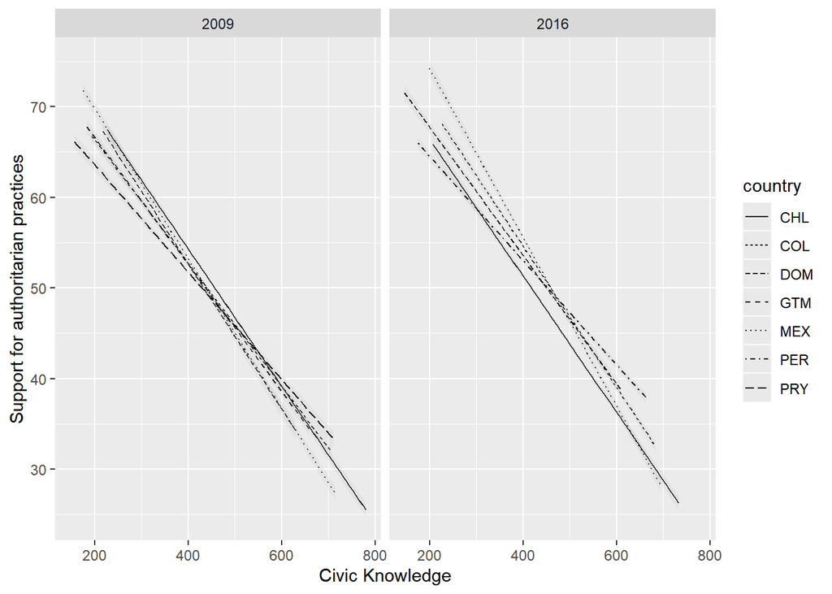

```r
#Students’ endorsement of authoritarian government practices
#IRT WLE scores with mean of 10 and standard deviation of 2 within each participating country
dicta <- ggplot(mergeiccs, aes(civic_knowledge, l_autgov, weight=totwgts, linetype = country))
dicta <-    dicta + geom_smooth(method = "lm", alpha = 0.1, color="black", size=0.5) +
      facet_wrap(~ time) +
    labs(x = "Civic Knowledge", y = "Support for authoritarian practices", colour = "dark")
dicta
```

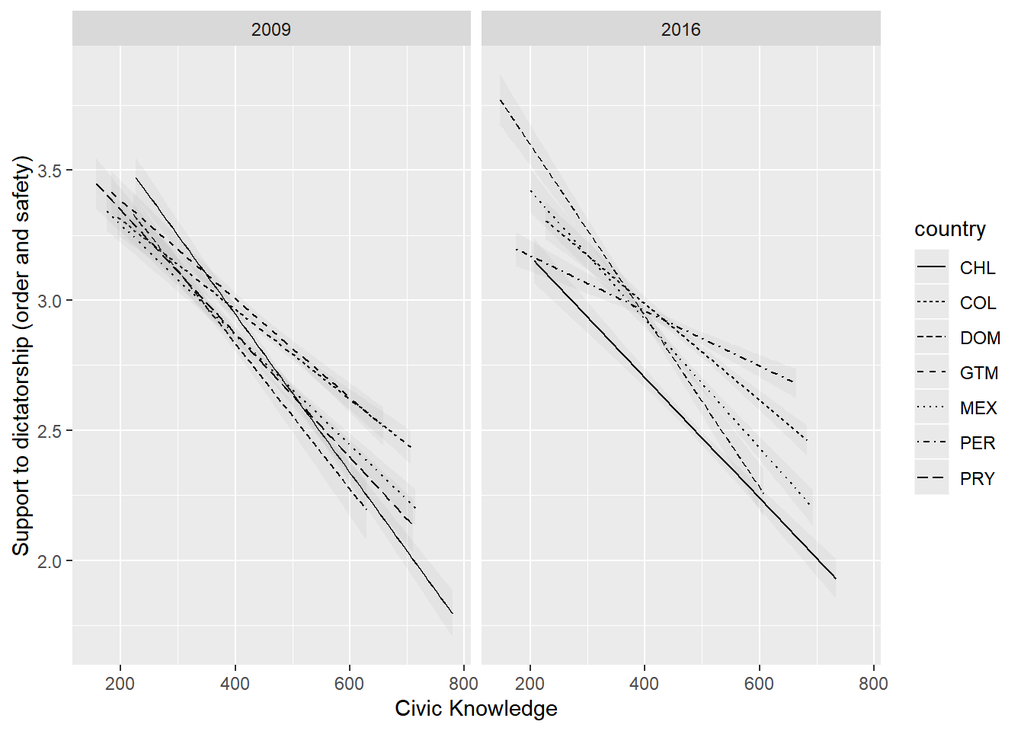

```r
#Dictatorships are justified when they bring order and safety
dicta1 <- ggplot(mergeiccs, aes(civic_knowledge, dicta_safety, weight=totwgts, linetype = country))
dicta1 <-    dicta1 + geom_smooth(method = "lm", alpha = 0.1, color="black", size=0.5) +
      facet_wrap(~ time) +
    labs(x = "Civic Knowledge", y = "Support to dictatorship (order and safety)", colour = "dark")
dicta1
```

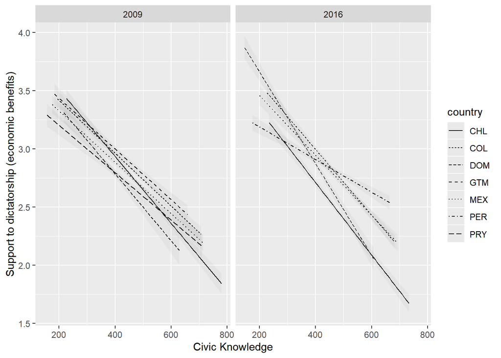

```r
#Dictatorships are justified when they bring economic benefits
dicta2 <- ggplot(mergeiccs, aes(civic_knowledge, dicta_benefits, weight=totwgts, linetype = country))
dicta2 <-    dicta2 + geom_smooth(method = "lm", alpha = 0.1, color="black", size=0.5) +
      facet_wrap(~ time) +
    labs(x = "Civic Knowledge", y = "Support to dictatorship (economic benefits)", colour = "dark")
dicta2
```

```r
#All graphs
library(ggpubr)
png(file = "C:/Users/DM/Dropbox (Personal)/book_authoritarianism/Resultados/graph/g1.png", height = 300)
ggarrange(dicta, ncol = 1, nrow = 1,  common.legend = TRUE, legend="right")
dev.off()
```

```r
png(file = "C:/Users/DM/Dropbox (Personal)/book_authoritarianism/Resultados/graph/g2.png", height = 430)
ggarrange(dicta1, dicta2, ncol = 1, nrow = 2,  common.legend = TRUE, legend="right")
dev.off()
```

## Institutuional Trust

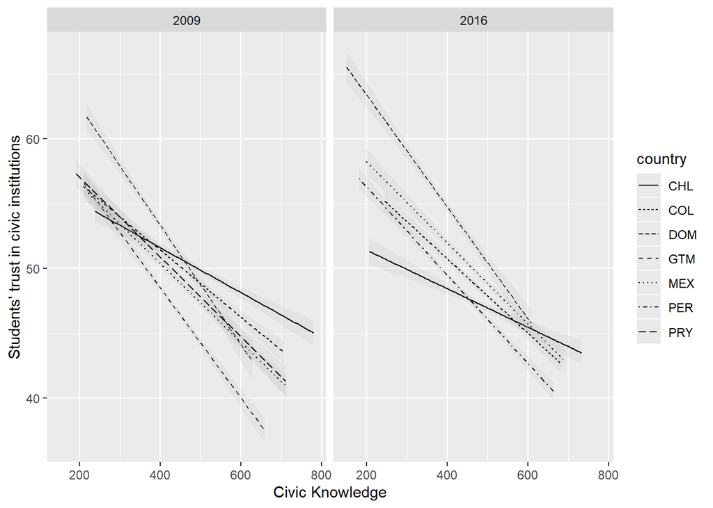

```r
#Students' trust in civic institutions
#IRT WLE scores with mean of 10 and standard deviation of 2 within each participating country
#National Goberment
#Local Goberment
#Courts of justice
#The police
#National Parliament

#Trust in civic institutions
trust <- ggplot(mergeiccs, aes(civic_knowledge, s_intrust, weight=totwgts, linetype = country))
trust <-    trust + geom_smooth(method = "lm", alpha = 0.1, color="black", size=0.5) +
      facet_wrap(~ time) +
    labs(x = "Civic Knowledge", y = "Students' trust in civic institutions", colour = "dark")
trust
```

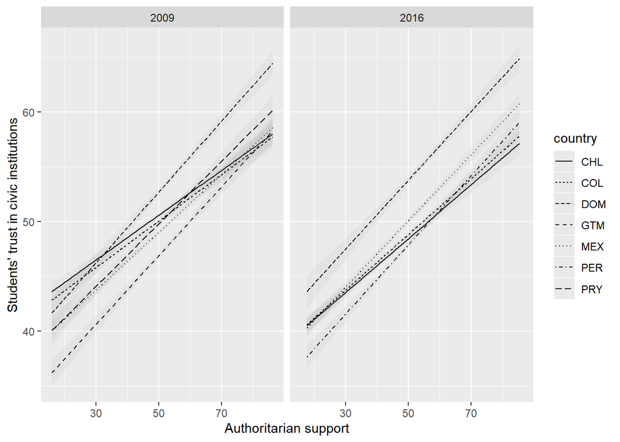

```r
#Trust in civic institutions
trust2 <- ggplot(mergeiccs, aes(l_autgov, s_intrust, weight=totwgts, linetype = country))
trust2 <-    trust2 + geom_smooth(method = "lm", alpha = 0.1, color="black", size=0.5) +
      facet_wrap(~ time) +
    labs(x = "Authoritarian support", y = "Students' trust in civic institutions", colour = "dark")
trust2
```

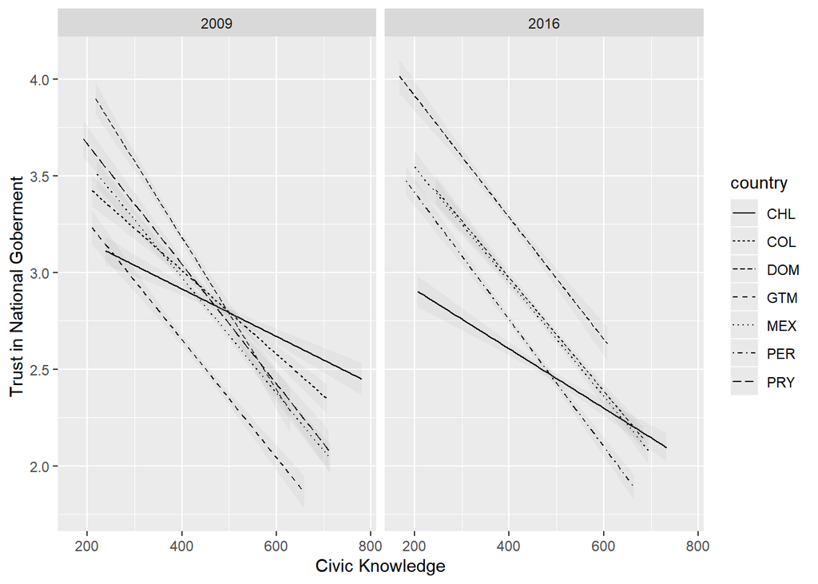

```r
#Trust in National Goberment
nac <- ggplot(mergeiccs, aes(civic_knowledge, nac_gob, weight=totwgts, linetype = country))
nac <-    nac + geom_smooth(method = "lm", alpha = 0.1, color="black", size=0.5) +
      facet_wrap(~ time) +
    labs(x = "Civic Knowledge", y = "Trust in National Goberment ", colour = "dark")
nac
```

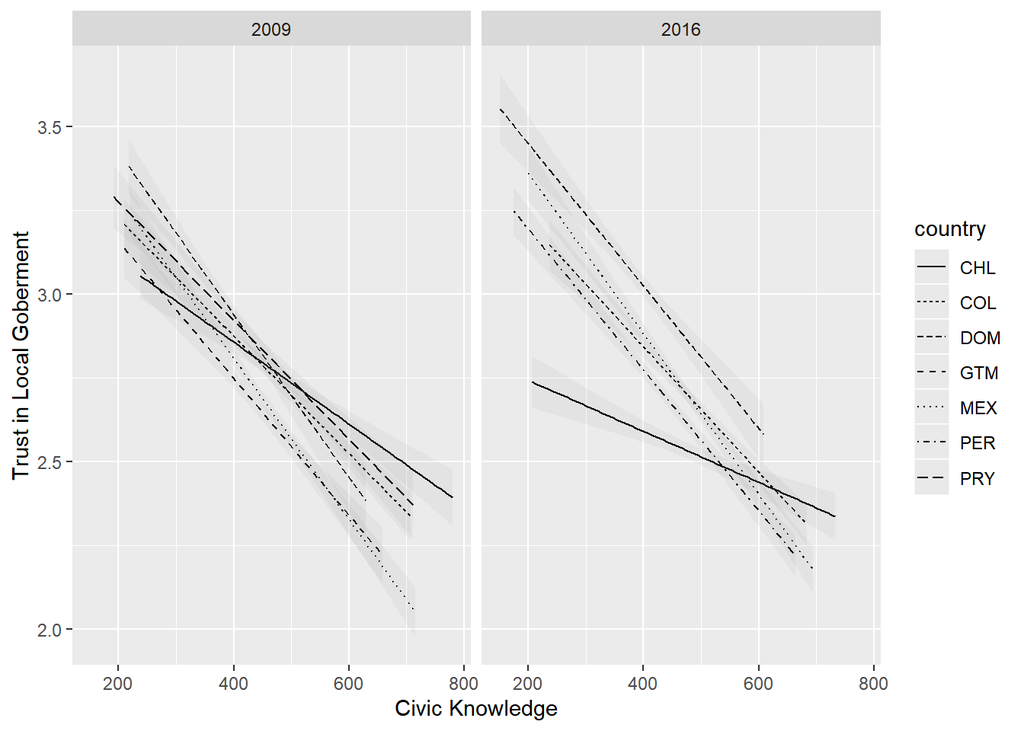

```r
#Trust in Local Goberment
local <- ggplot(mergeiccs, aes(civic_knowledge, local_gob, weight=totwgts, linetype = country))
local <-    local + geom_smooth(method = "lm", alpha = 0.1, color="black", size=0.5) +
      facet_wrap(~ time) +
    labs(x = "Civic Knowledge", y = "Trust in Local Goberment", colour = "dark")
local
```

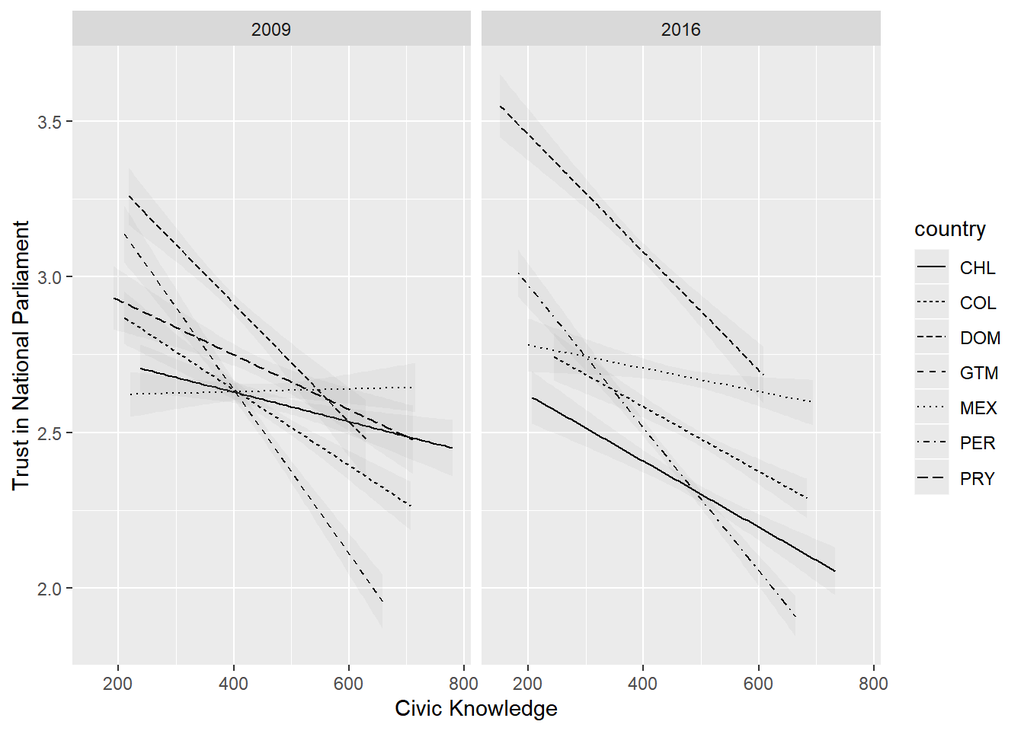

```r
#Trust National Parliament
parliament <- ggplot(mergeiccs, aes(civic_knowledge, parliament, weight=totwgts, linetype = country))
parliament <-    parliament + geom_smooth(method = "lm", alpha = 0.1, color="black", size=0.5) +
      facet_wrap(~ time) +
    labs(x = "Civic Knowledge", y = "Trust in National Parliament", colour = "dark")
parliament
```

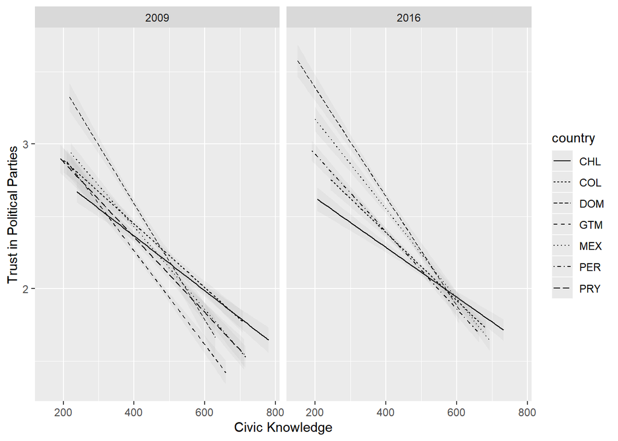

```r
#Political Parties
parties <- ggplot(mergeiccs, aes(civic_knowledge, pol_parties, weight=totwgts, linetype = country))
parties <-    parties + geom_smooth(method = "lm", alpha = 0.1, color="black", size=0.5) +
      facet_wrap(~ time) +
    labs(x = "Civic Knowledge", y = "Trust in Political Parties", colour = "dark")
parties
```

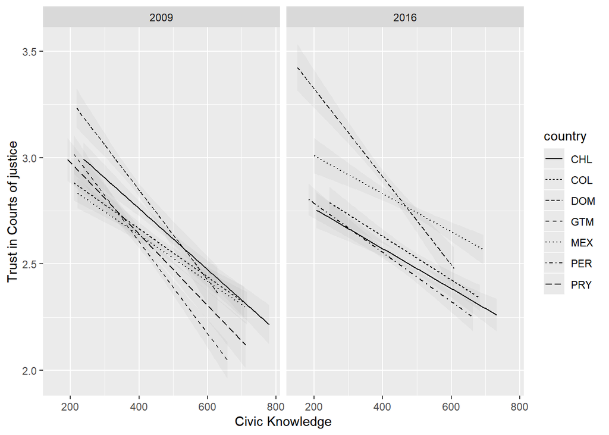

```r
#Trust Courts of justice
courts <- ggplot(mergeiccs, aes(civic_knowledge, courts, weight=totwgts, linetype = country))
courts <-    courts + geom_smooth(method = "lm", alpha = 0.1, color="black", size=0.5) +
      facet_wrap(~ time) +
    labs(x = "Civic Knowledge", y = "Trust in Courts of justice", colour = "dark")
courts
```

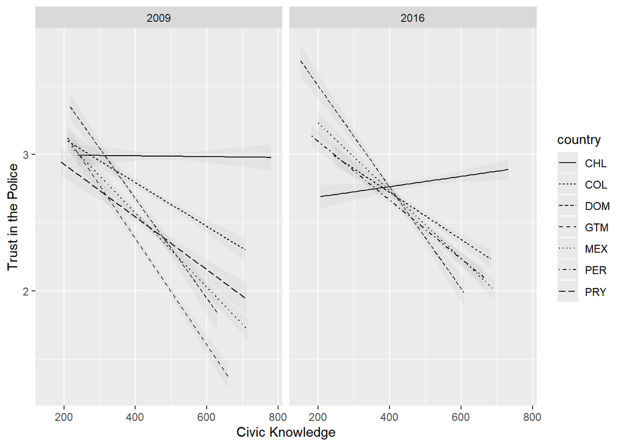

```r
#Trust The police
police <- ggplot(mergeiccs, aes(civic_knowledge, police, weight=totwgts, linetype = country))
police <-    police + geom_smooth(method = "lm", alpha = 0.1, color="black", size=0.5) +
      facet_wrap(~ time) +
    labs(x = "Civic Knowledge", y = "Trust in the Police", colour = "dark")
police
```

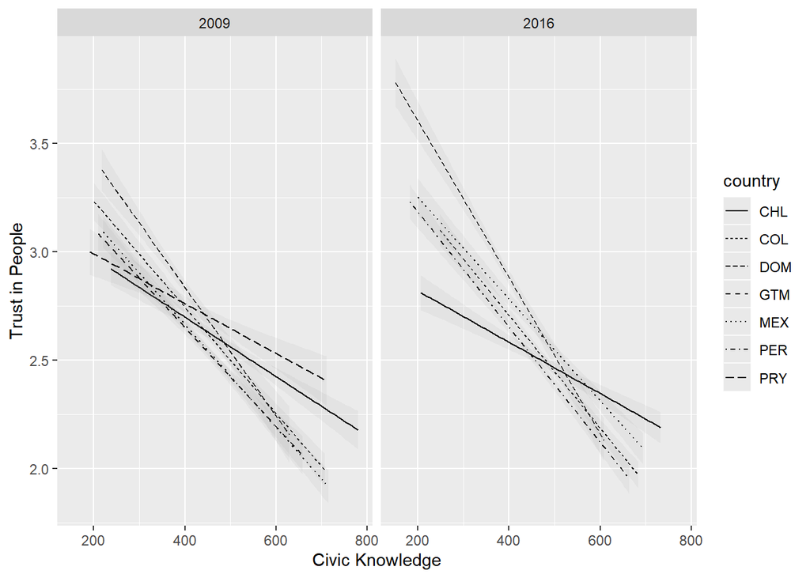

```r
#Trust people in general
people <- ggplot(mergeiccs, aes(civic_knowledge, people, weight=totwgts, linetype = country))
people <-    people + geom_smooth(method = "lm", alpha = 0.1, color="black", size=0.5) +
      facet_wrap(~ time) +
    labs(x = "Civic Knowledge", y = "Trust in People", colour = "dark")
people
```

```r
#All graphs
png(file = "C:/Users/DM/Dropbox (Personal)/book_authoritarianism/Resultados/graph/g3.png", height = 300)
ggarrange(trust, ncol = 1, nrow = 1,  common.legend = TRUE, legend="right")
dev.off()
```

```r
png(file = "C:/Users/DM/Dropbox (Personal)/book_authoritarianism/Resultados/graph/g3b.png", height = 300)
ggarrange(trust2, ncol = 1, nrow = 1,  common.legend = TRUE, legend="right")
dev.off()
```

```r
png(file = "C:/Users/DM/Dropbox (Personal)/book_authoritarianism/Resultados/graph/g4.png", height = 430)
ggarrange(nac, local, ncol = 1, nrow = 2,  common.legend = TRUE, legend="right")
dev.off()
```

```r
png(file = "C:/Users/DM/Dropbox (Personal)/book_authoritarianism/Resultados/graph/g5.png", height = 430)
ggarrange(parliament, parties, ncol = 1, nrow = 2,  common.legend = TRUE, legend="right")
dev.off()
```

```r
png(file = "C:/Users/DM/Dropbox (Personal)/book_authoritarianism/Resultados/graph/g6.png", height = 430)
ggarrange(courts, police, ncol = 1, nrow = 2,  common.legend = TRUE, legend="right")
dev.off()
```

```r
png(file = "C:/Users/DM/Dropbox (Personal)/book_authoritarianism/Resultados/graph/g7.png", height = 300)
ggarrange(people, ncol = 1, nrow = 1,  common.legend = TRUE, legend="right")
dev.off()
```

## Interaction

```r
#Modelos de regresión
#VD: Trust
#VD: Support authoritarianism
#VI: Trust
#VC: Nivel educacional de los padres, Libros en la casa, género del estudiante, nivel de discusión política, cohortes

##########################################################3
#OLS
##########################################################3
#VD: Support authoritarianism
m1 <- lm(l_autgov ~ civic_knowledge , data=mergeiccs, w=totwgts)
m2 <- lm(l_autgov ~ civic_knowledge + s_hisced + s_homelit + s_gender + s_poldisc, data=mergeiccs, w=totwgts)
m3 <- lm(l_autgov ~ civic_knowledge + s_hisced + s_homelit + s_gender + s_poldisc + factor(time) + factor(idcountry), data=mergeiccs, w=totwgts)

summary(m3)
```

Call: lm(formula = l_autgov ~ civic_knowledge + s_hisced + s_homelit + s_gender + s_poldisc + factor(time) + factor(idcountry), data = mergeiccs, weights = totwgts)

Weighted Residuals: Min 1Q Median 3Q Max -1200.28 -35.35 6.71 44.62 825.45

Coefficients: Estimate Std. Error t value Pr(>|t|)  
(Intercept) 85.4372913 0.3357651 254.456 < 0.0000000000000002 *civic_knowledge -0.0793543 0.0005124 -154.854 < 0.0000000000000002* s_hisced 0.0457209 0.0285430 1.602 0.109200  
s_homelit -0.2327802 0.0366456 -6.352 0.000000000214 *s_gender -1.3150772 0.0768900 -17.103 < 0.0000000000000002* s_poldisc -0.0005511 0.0040444 -0.136 0.891606  
factor(time)2016 1.0401339 0.0848272 12.262 < 0.0000000000000002 *factor(idcountry)170 0.7941203 0.1685824 4.711 0.000002476532* factor(idcountry)214 -0.4167443 0.2477346 -1.682 0.092532 .  
factor(idcountry)320 0.1032563 0.3191145 0.324 0.746264  
factor(idcountry)484 0.5492984 0.1528144 3.595 0.000325 *** factor(idcountry)600 -0.4963251 0.3862910 -1.285 0.198851  
factor(idcountry)604 0.0631990 0.2084167 0.303 0.761713  
— Signif. codes: 0 ‘**’ 0.001 ’**’ 0.01 ’’ 0.05 ‘.’ 0.1 ’ ’ 1

Residual standard error: 99.04 on 52135 degrees of freedom (3067 observations deleted due to missingness) Multiple R-squared: 0.364, Adjusted R-squared: 0.3638 F-statistic: 2486 on 12 and 52135 DF, p-value: < 0.00000000000000022

```r
coef(m2)[1]+(coef(m2)[2]*562)
```

(Intercept) 42.30073

```r
coef(m2)[1]+(coef(m2)[2]*311)
```

(Intercept) 61.78515

```r
#VD: Trust
m4 <- lm(s_intrust ~ civic_knowledge, data=mergeiccs, w=totwgts)

m5 <- lm(s_intrust ~ civic_knowledge + l_autgov , data=mergeiccs, w=totwgts)

m6 <- lm(s_intrust ~ civic_knowledge*l_autgov, data=mergeiccs, w=totwgts)

m7 <- lm(s_intrust ~ civic_knowledge*l_autgov + s_hisced + s_homelit + s_gender + s_poldisc, data=mergeiccs, w=totwgts)

m8 <- lm(s_intrust ~ civic_knowledge*l_autgov + s_hisced + s_homelit + s_gender + s_poldisc + factor(time) + factor(idcountry), data=mergeiccs, w=totwgts)

summary(m5)
```

Call: lm(formula = s_intrust ~ civic_knowledge + l_autgov, data = mergeiccs, weights = totwgts)

Weighted Residuals: Min 1Q Median 3Q Max -1031.62 -54.23 -5.40 48.67 1078.49

Coefficients: Estimate Std. Error t value Pr(>|t|)  
(Intercept) 42.8869120 0.5058082 84.79 <0.0000000000000002 *civic_knowledge -0.0109151 0.0006818 -16.01 <0.0000000000000002* l_autgov 0.2332272 0.0050399 46.28 <0.0000000000000002 *** — Signif. codes: 0 ‘**’ 0.001 ’**’ 0.01 ’’ 0.05 ‘.’ 0.1 ’ ’ 1

Residual standard error: 114.5 on 51791 degrees of freedom (3421 observations deleted due to missingness) Multiple R-squared: 0.09054, Adjusted R-squared: 0.0905 F-statistic: 2578 on 2 and 51791 DF, p-value: < 0.00000000000000022

```r
coef(m5)[1]+(coef(m5)[2]*311)
```

(Intercept) 39.4923

```r
coef(m5)[1]+(coef(m5)[2]*562)
```

(Intercept) 36.7526

```r
#Table
#library(texreg)
#print(xtable(iccs_count[, c(2:1,6,3:5)],  caption = "Sample", format="text"), include.rownames=FALSE)
#texreg(list(m1, m2, m3), digits = 2)
texreg(list(m4, m5, m6, m7, m8), digits = 2)
```

```r
htmlreg(list(m1, m2, m3),  caption = "VD: Support authoritarianism")
```

<!DOCTYPE HTML PUBLIC “-//W3C//DTD HTML 4.01 Transitional//EN” “http://www.w3.org/TR/html4/loose.dtd”>

VD: Support authoritarianism

|  | **Model 1** | **Model 2** | **Model 3** |  |
| --- | --- | --- | --- | --- |
| (Intercept) | 85.49*** | 85.93*** | 85.44*** |  |
|  | (0.21) | (0.30) | (0.34) |  |
| civic_knowledge | -0.08*** | -0.08*** | -0.08*** |  |
|  | (0.00) | (0.00) | (0.00) |  |
| s_hisced |  | -0.06* | 0.05 |  |
|  |  | (0.03) | (0.03) |  |
| s_homelit |  | -0.28*** | -0.23*** |  |
|  |  | (0.04) | (0.04) |  |
| s_gender |  | -1.37*** | -1.32*** |  |
|  |  | (0.08) | (0.08) |  |
| s_poldisc |  | 0.00 | -0.00 |  |
|  |  | (0.00) | (0.00) |  |
| factor(time)2016 |  |  | 1.04*** |  |
|  |  |  | (0.08) |  |
| factor(idcountry)170 |  |  | 0.79*** |  |
|  |  |  | (0.17) |  |
| factor(idcountry)214 |  |  | -0.42 |  |
|  |  |  | (0.25) |  |
| factor(idcountry)320 |  |  | 0.10 |  |
|  |  |  | (0.32) |  |
| factor(idcountry)484 |  |  | 0.55*** |  |
|  |  |  | (0.15) |  |
| factor(idcountry)600 |  |  | -0.50 |  |
|  |  |  | (0.39) |  |
| factor(idcountry)604 |  |  | 0.06 |  |
|  |  |  | (0.21) |  |
| R<sup>2</sup> | 0.36 | 0.36 | 0.36 |  |
| Adj. R<sup>2</sup> | 0.36 | 0.36 | 0.36 |  |
| Num. obs. | 54769 | 52148 | 52148 |  |
| RMSE | 99.05 | 99.25 | 99.04 |  |
| p < 0.001, p < 0.01, p < 0.05 |  |  |  |  |

```r
htmlreg(list(m4, m5, m6, m7, m8),  caption = "VD: Institutional Trusts")
```

<!DOCTYPE HTML PUBLIC “-//W3C//DTD HTML 4.01 Transitional//EN” “http://www.w3.org/TR/html4/loose.dtd”>

VD: Institutional Trusts

|  | **Model 1** | **Model 2** | **Model 3** | **Model 4** | **Model 5** |  |
| --- | --- | --- | --- | --- | --- | --- |
| (Intercept) | 63.10*** | 42.89*** | 13.74*** | 11.94*** | 13.20*** |  |
|  | (0.26) | (0.51) | (1.25) | (1.28) | (1.29) |  |
| civic_knowledge | -0.03*** | -0.01*** | 0.05*** | 0.04*** | 0.04*** |  |
|  | (0.00) | (0.00) | (0.00) | (0.00) | (0.00) |  |
| l_autgov |  | 0.23*** | 0.81*** | 0.75*** | 0.72*** |  |
|  |  | (0.01) | (0.02) | (0.02) | (0.02) |  |
| civic_knowledge:l_autgov |  |  | -0.00*** | -0.00*** | -0.00*** |  |
|  |  |  | (0.00) | (0.00) | (0.00) |  |
| s_hisced |  |  |  | 0.02 | -0.02 |  |
|  |  |  |  | (0.03) | (0.03) |  |
| s_homelit |  |  |  | -0.31*** | -0.27*** |  |
|  |  |  |  | (0.04) | (0.04) |  |
| s_gender |  |  |  | -0.67*** | -0.73*** |  |
|  |  |  |  | (0.09) | (0.09) |  |
| s_poldisc |  |  |  | 0.11*** | 0.11*** |  |
|  |  |  |  | (0.00) | (0.00) |  |
| factor(time)2016 |  |  |  |  | 0.06 |  |
|  |  |  |  |  | (0.10) |  |
| factor(idcountry)170 |  |  |  |  | -0.32 |  |
|  |  |  |  |  | (0.19) |  |
| factor(idcountry)214 |  |  |  |  | 2.61*** |  |
|  |  |  |  |  | (0.29) |  |
| factor(idcountry)320 |  |  |  |  | -3.47*** |  |
|  |  |  |  |  | (0.37) |  |
| factor(idcountry)484 |  |  |  |  | -0.19 |  |
|  |  |  |  |  | (0.18) |  |
| factor(idcountry)600 |  |  |  |  | -0.25 |  |
|  |  |  |  |  | (0.46) |  |
| factor(idcountry)604 |  |  |  |  | -2.51*** |  |
|  |  |  |  |  | (0.24) |  |
| R<sup>2</sup> | 0.05 | 0.09 | 0.10 | 0.11 | 0.12 |  |
| Adj. R<sup>2</sup> | 0.05 | 0.09 | 0.10 | 0.11 | 0.12 |  |
| Num. obs. | 51954 | 51794 | 51794 | 50281 | 50281 |  |
| RMSE | 117.01 | 114.45 | 113.75 | 113.41 | 112.94 |  |
| p < 0.001, p < 0.01, p < 0.05 |  |  |  |  |  |  |

```r
#Plot
library(sjPlot)
png(file = "C:/Users/DM/Dropbox (Personal)/book_authoritarianism/Resultados/graph/g8.png", height = 300)
dev.off()
```

png 2

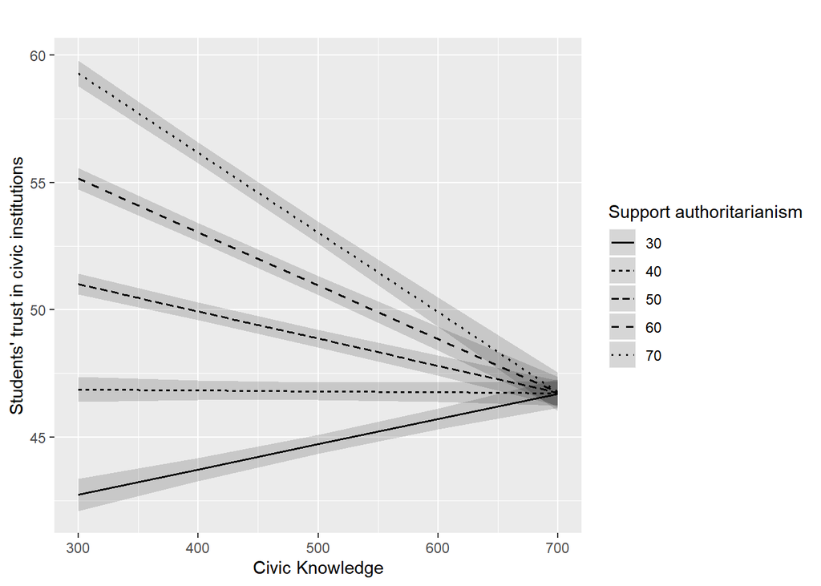

```r
plot2 <- plot_model(m8, type = "pred", terms = c("civic_knowledge[300, 400, 500, 600, 700]", "l_autgov[30, 40, 50, 60 ,70]"), colors = 'bw', axis.title = c("Civic Knowledge", "Students' trust in civic institutions"), title = c(""), legend.title = "Support authoritarianism")


plot2
```

```r
png(file = "C:/Users/DM/Dropbox (Personal)/book_authoritarianism/Resultados/graph/g8.png", height = 300)
ggarrange(plot2, ncol = 1, nrow = 1,  common.legend = TRUE, legend="right")
dev.off()
```

png 2

```r
#Plot
library(sjPlot)
png(file = "C:/Users/DM/Dropbox (Personal)/book_authoritarianism/Resultados/graph/g8b.png", height = 300)
dev.off()
```

png 2

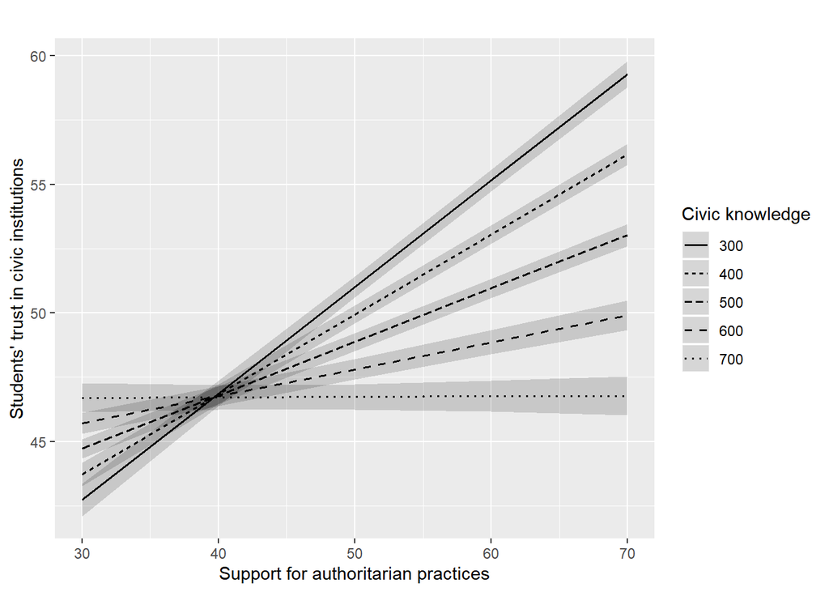

```r
plot3 <- plot_model(m8, type = "pred", terms = c("l_autgov[30, 40, 50, 60 ,70]", "civic_knowledge[300, 400, 500, 600, 700]"), colors = 'bw', axis.title = c("Support for authoritarian practices", "Students' trust in civic institutions"), title = c(""), legend.title = "Civic knowledge")


plot3
```

```r
png(file = "C:/Users/DM/Dropbox (Personal)/book_authoritarianism/Resultados/graph/g8b.png", height = 300)
ggarrange(plot3, ncol = 1, nrow = 1,  common.legend = TRUE, legend="right")
dev.off()
```

png 2

# OLS by chile

```r
##########################################################3
#OLS
##########################################################3
#Borramos los modelos generados en el apartado anterior
rm(list=(ls()[!ls() %in% ("mergeiccs")]))

chi <- mergeiccs  %>% filter(idcountry == 152)

#VD: Support authoritarianism
library(miceadds)
m1 <- lm(l_autgov ~ s_intrust + civic_knowledge, data=chi, w=totwgts)
m2 <- lm(l_autgov ~ s_intrust + civic_knowledge + s_hisced + s_homelit + s_gender + s_poldisc + time, data=chi, w=totwgts)
m3 <- lm(l_autgov ~ s_intrust*civic_knowledge + s_hisced + s_homelit + s_gender + s_poldisc + time, data=chi, w=totwgts)

#VD: Trust
m4 <- lm(s_intrust ~ civic_knowledge, data=chi, w=totwgts)
m5 <- lm(s_intrust ~ civic_knowledge + s_hisced + s_homelit + s_gender + s_poldisc + time, data=chi, w=totwgts)

#Table
#print(xtable(iccs_count[, c(2:1,6,3:5)],  caption = "Sample", format="text"), include.rownames=FALSE)
#texreg(list(m1, m2, m3, m4, m5), digits = 2)
#htmlreg(list(m1, m2, m3, m4, m5), digits = 4)
htmlreg(list(m1, m2, m3),  caption = "VD: Support authoritarianism")
```

<!DOCTYPE HTML PUBLIC “-//W3C//DTD HTML 4.01 Transitional//EN” “http://www.w3.org/TR/html4/loose.dtd”>

VD: Support authoritarianism

|  | **Model 1** | **Model 2** | **Model 3** |  |
| --- | --- | --- | --- | --- |
| (Intercept) | 72.44*** | 793.05*** | 792.12*** |  |
|  | (0.71) | (56.41) | (56.36) |  |
| s_intrust | 0.20*** | 0.18*** | 0.37*** |  |
|  | (0.01) | (0.01) | (0.05) |  |
| civic_knowledge | -0.07*** | -0.07*** | -0.05*** |  |
|  | (0.00) | (0.00) | (0.00) |  |
| s_hisced |  | -0.02 | -0.02 |  |
|  |  | (0.09) | (0.09) |  |
| s_homelit |  | -0.14 | -0.14 |  |
|  |  | (0.09) | (0.09) |  |
| s_gender |  | -0.67*** | -0.67*** |  |
|  |  | (0.18) | (0.18) |  |
| s_poldisc |  | 0.01 | 0.01 |  |
|  |  | (0.01) | (0.01) |  |
| time |  | -0.36*** | -0.36*** |  |
|  |  | (0.03) | (0.03) |  |
| s_intrust:civic_knowledge |  |  | -0.00*** |  |
|  |  |  | (0.00) |  |
| R<sup>2</sup> | 0.36 | 0.38 | 0.38 |  |
| Adj. R<sup>2</sup> | 0.36 | 0.38 | 0.38 |  |
| Num. obs. | 10071 | 9855 | 9855 |  |
| RMSE | 62.81 | 62.23 | 62.18 |  |
| p < 0.001, p < 0.01, p < 0.05 |  |  |  |  |

```r
htmlreg(list(m4, m5),  caption = "VD: Institutional Trusts")
```

<!DOCTYPE HTML PUBLIC “-//W3C//DTD HTML 4.01 Transitional//EN” “http://www.w3.org/TR/html4/loose.dtd”>

VD: Institutional Trusts

|  | **Model 1** | **Model 2** |  |
| --- | --- | --- | --- |
| (Intercept) | 56.49*** | 949.93*** |  |
|  | (0.61) | (64.44) |  |
| civic_knowledge | -0.02*** | -0.02*** |  |
|  | (0.00) | (0.00) |  |
| s_hisced |  | -0.08 |  |
|  |  | (0.11) |  |
| s_homelit |  | -0.21* |  |
|  |  | (0.10) |  |
| s_gender |  | -0.86*** |  |
|  |  | (0.21) |  |
| s_poldisc |  | 0.13*** |  |
|  |  | (0.01) |  |
| time |  | -0.45*** |  |
|  |  | (0.03) |  |
| R<sup>2</sup> | 0.02 | 0.05 |  |
| Adj. R<sup>2</sup> | 0.02 | 0.05 |  |
| Num. obs. | 10089 | 9873 |  |
| RMSE | 73.29 | 71.94 |  |
| p < 0.001, p < 0.01, p < 0.05 |  |  |  |

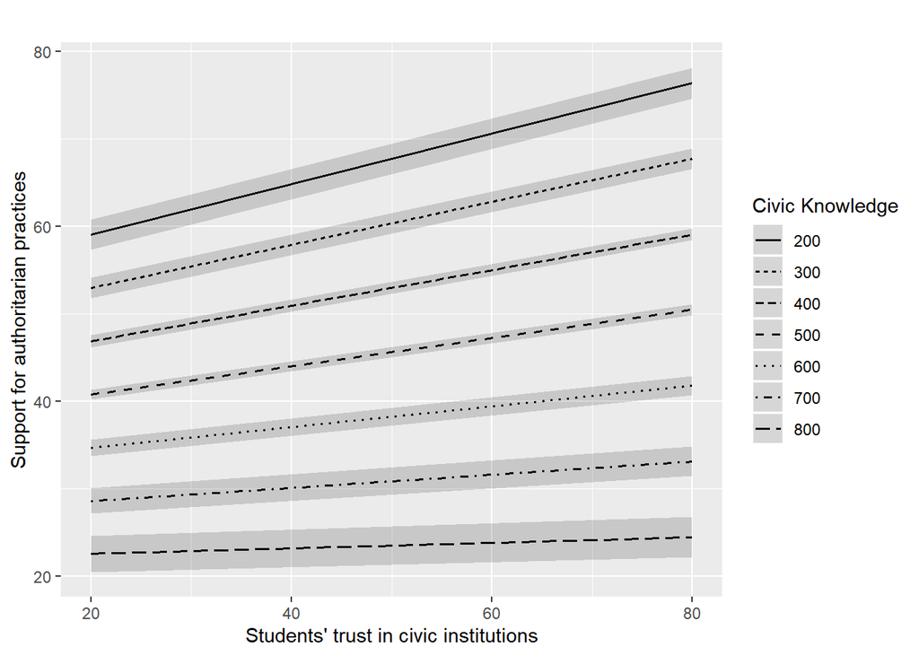

```r
plot2 <- plot_model(m3, type = "pred", terms = c("s_intrust[20,80]", "civic_knowledge[200, 300, 400, 500, 600, 700, 800]"), colors = 'bw', axis.title = c("Students' trust in civic institutions", "Support for authoritarian practices"), title = c(""), legend.title = "Civic Knowledge")

plot2
```

# OLS by Colombia

```r
##########################################################3
#OLS
##########################################################3
#Borramos los modelos generados en el apartado anterior
rm(list=(ls()[!ls() %in% ("mergeiccs")]))

col <- mergeiccs  %>% filter(idcountry == 170)

#VD: Support authoritarianism
m1 <- lm(l_autgov ~ s_intrust + civic_knowledge, data=col, w=totwgts)
m2 <- lm(l_autgov ~ s_intrust + civic_knowledge + s_hisced + s_homelit + s_gender + s_poldisc + time, data=col, w=totwgts)
m3 <- lm(l_autgov ~ s_intrust*civic_knowledge + s_hisced + s_homelit + s_gender + s_poldisc + time, data=col, w=totwgts)

#VD: Trust
m4 <- lm(s_intrust ~ civic_knowledge, data=col, w=totwgts)
m5 <- lm(s_intrust ~ civic_knowledge + s_hisced + s_homelit + s_gender + s_poldisc + time, data=col, w=totwgts)

#Table
#print(xtable(iccs_count[, c(2:1,6,3:5)],  caption = "Sample", format="text"), include.rownames=FALSE)
#texreg(list(m1, m2, m3, m4, m5), digits = 2)
#htmlreg(list(m1, m2, m3, m4, m5), digits = 4)
htmlreg(list(m1, m2, m3),  caption = "VD: Support authoritarianism")
```

<!DOCTYPE HTML PUBLIC “-//W3C//DTD HTML 4.01 Transitional//EN” “http://www.w3.org/TR/html4/loose.dtd”>

VD: Support authoritarianism

|  | **Model 1** | **Model 2** | **Model 3** |  |
| --- | --- | --- | --- | --- |
| (Intercept) | 77.16*** | -268.35*** | -268.65*** |  |
|  | (0.66) | (44.89) | (44.89) |  |
| s_intrust | 0.10*** | 0.11*** | 0.16*** |  |
|  | (0.01) | (0.01) | (0.05) |  |
| civic_knowledge | -0.07*** | -0.07*** | -0.07*** |  |
|  | (0.00) | (0.00) | (0.00) |  |
| s_hisced |  | 0.07 | 0.07 |  |
|  |  | (0.05) | (0.05) |  |
| s_homelit |  | -0.13 | -0.13 |  |
|  |  | (0.07) | (0.07) |  |
| s_gender |  | -1.28*** | -1.28*** |  |
|  |  | (0.15) | (0.15) |  |
| s_poldisc |  | -0.03*** | -0.03*** |  |
|  |  | (0.01) | (0.01) |  |
| time |  | 0.17*** | 0.17*** |  |
|  |  | (0.02) | (0.02) |  |
| s_intrust:civic_knowledge |  |  | -0.00 |  |
|  |  |  | (0.00) |  |
| R<sup>2</sup> | 0.35 | 0.36 | 0.36 |  |
| Adj. R<sup>2</sup> | 0.35 | 0.36 | 0.36 |  |
| Num. obs. | 11233 | 11038 | 11038 |  |
| RMSE | 83.19 | 82.73 | 82.72 |  |
| p < 0.001, p < 0.01, p < 0.05 |  |  |  |  |

```r
htmlreg(list(m4, m5),  caption = "VD: Institutional Trusts")
```

<!DOCTYPE HTML PUBLIC “-//W3C//DTD HTML 4.01 Transitional//EN” “http://www.w3.org/TR/html4/loose.dtd”>

VD: Institutional Trusts

|  | **Model 1** | **Model 2** |  |
| --- | --- | --- | --- |
| (Intercept) | 62.34*** | 258.87*** |  |
|  | (0.59) | (55.83) |  |
| civic_knowledge | -0.03*** | -0.03*** |  |
|  | (0.00) | (0.00) |  |
| s_hisced |  | 0.24*** |  |
|  |  | (0.06) |  |
| s_homelit |  | -0.24** |  |
|  |  | (0.09) |  |
| s_gender |  | -1.80*** |  |
|  |  | (0.18) |  |
| s_poldisc |  | 0.16*** |  |
|  |  | (0.01) |  |
| time |  | -0.10*** |  |
|  |  | (0.03) |  |
| R<sup>2</sup> | 0.04 | 0.08 |  |
| Adj. R<sup>2</sup> | 0.04 | 0.08 |  |
| Num. obs. | 11262 | 11064 |  |
| RMSE | 105.09 | 103.12 |  |
| p < 0.001, p < 0.01, p < 0.05 |  |  |  |

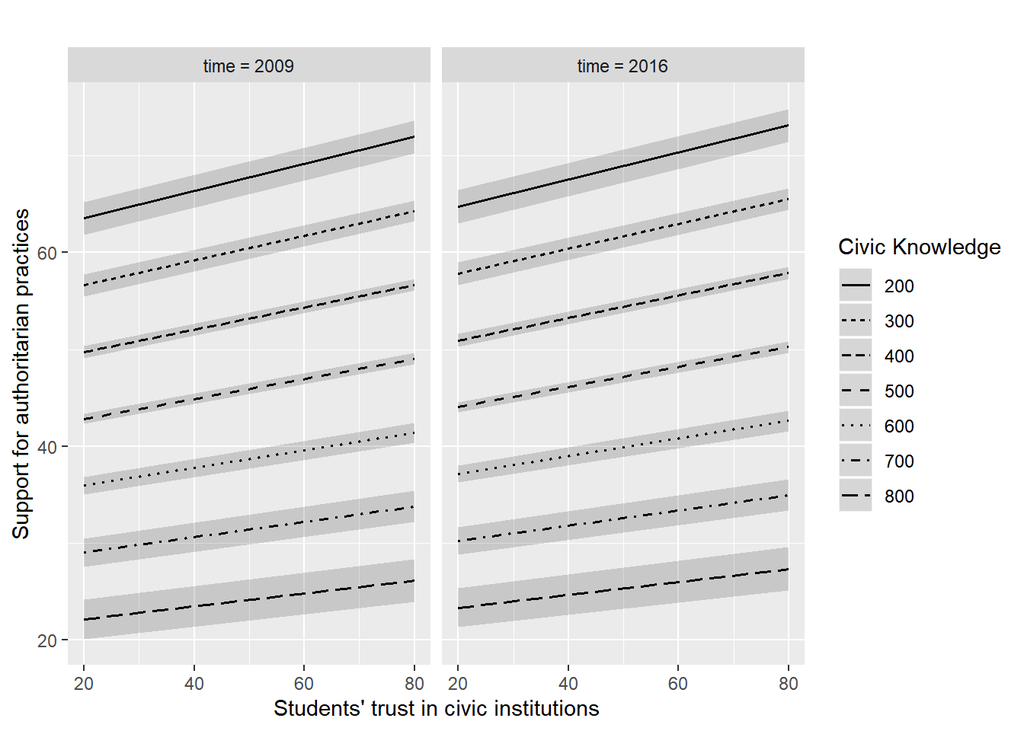

```r
plot2 <- plot_model(m3, type = "pred", terms = c("s_intrust[20,80]", "civic_knowledge[200, 300, 400, 500, 600, 700, 800]", "time"), colors = 'bw', axis.title = c("Students' trust in civic institutions", "Support for authoritarian practices"), title = c(""), legend.title = "Civic Knowledge")

plot2
```

# OLS by Dominican Republic

```r
##########################################################3
#OLS
##########################################################3
#Borramos los modelos generados en el apartado anterior
rm(list=(ls()[!ls() %in% ("mergeiccs")]))

dom <- mergeiccs  %>% filter(idcountry == 214)

#VD: Support authoritarianism
m1 <- lm(l_autgov ~ s_intrust + civic_knowledge, data=dom, w=totwgts)
m2 <- lm(l_autgov ~ s_intrust + civic_knowledge + s_hisced + s_homelit + s_gender + s_poldisc + time, data=dom, w=totwgts)
m3 <- lm(l_autgov ~ s_intrust*civic_knowledge + s_hisced + s_homelit + s_gender + s_poldisc + time, data=dom, w=totwgts)

#VD: Trust
m4 <- lm(s_intrust ~ civic_knowledge, data=dom, w=totwgts)
m5 <- lm(s_intrust ~ civic_knowledge + s_hisced + s_homelit + s_gender + s_poldisc + time, data=dom, w=totwgts)

#Table
#print(xtable(iccs_count[, c(2:1,6,3:5)],  caption = "Sample", format="text"), include.rownames=FALSE)
#texreg(list(m1, m2, m3, m4, m5), digits = 2)
#htmlreg(list(m1, m2, m3, m4, m5), digits = 4)
htmlreg(list(m1, m2, m3),  caption = "VD: Support authoritarianism")
```

<!DOCTYPE HTML PUBLIC “-//W3C//DTD HTML 4.01 Transitional//EN” “http://www.w3.org/TR/html4/loose.dtd”>

VD: Support authoritarianism

|  | **Model 1** | **Model 2** | **Model 3** |  |
| --- | --- | --- | --- | --- |
| (Intercept) | 74.97*** | -169.07** | -169.51** |  |
|  | (0.85) | (60.43) | (60.43) |  |
| s_intrust | 0.13*** | 0.12*** | 0.17** |  |
|  | (0.01) | (0.01) | (0.05) |  |
| civic_knowledge | -0.07*** | -0.07*** | -0.07*** |  |
|  | (0.00) | (0.00) | (0.01) |  |
| s_hisced |  | 0.03 | 0.03 |  |
|  |  | (0.08) | (0.08) |  |
| s_homelit |  | -0.44*** | -0.44*** |  |
|  |  | (0.10) | (0.10) |  |
| s_gender |  | -0.85*** | -0.85*** |  |
|  |  | (0.21) | (0.21) |  |
| s_poldisc |  | -0.02 | -0.02 |  |
|  |  | (0.01) | (0.01) |  |
| time |  | 0.12*** | 0.12*** |  |
|  |  | (0.03) | (0.03) |  |
| s_intrust:civic_knowledge |  |  | -0.00 |  |
|  |  |  | (0.00) |  |
| R<sup>2</sup> | 0.31 | 0.32 | 0.32 |  |
| Adj. R<sup>2</sup> | 0.31 | 0.32 | 0.32 |  |
| Num. obs. | 7117 | 6655 | 6655 |  |
| RMSE | 48.31 | 47.95 | 47.95 |  |
| p < 0.001, p < 0.01, p < 0.05 |  |  |  |  |

```r
htmlreg(list(m4, m5),  caption = "VD: Institutional Trusts")
```

<!DOCTYPE HTML PUBLIC “-//W3C//DTD HTML 4.01 Transitional//EN” “http://www.w3.org/TR/html4/loose.dtd”>

VD: Institutional Trusts

|  | **Model 1** | **Model 2** |  |
| --- | --- | --- | --- |
| (Intercept) | 71.67*** | -228.12** |  |
|  | (0.75) | (79.93) |  |
| civic_knowledge | -0.04*** | -0.04*** |  |
|  | (0.00) | (0.00) |  |
| s_hisced |  | -0.12 |  |
|  |  | (0.10) |  |
| s_homelit |  | -0.17 |  |
|  |  | (0.13) |  |
| s_gender |  | -1.58*** |  |
|  |  | (0.27) |  |
| s_poldisc |  | 0.09*** |  |
|  |  | (0.01) |  |
| time |  | 0.15*** |  |
|  |  | (0.04) |  |
| R<sup>2</sup> | 0.07 | 0.09 |  |
| Adj. R<sup>2</sup> | 0.07 | 0.09 |  |
| Num. obs. | 7160 | 6685 |  |
| RMSE | 64.17 | 63.62 |  |
| p < 0.001, p < 0.01, p < 0.05 |  |  |  |

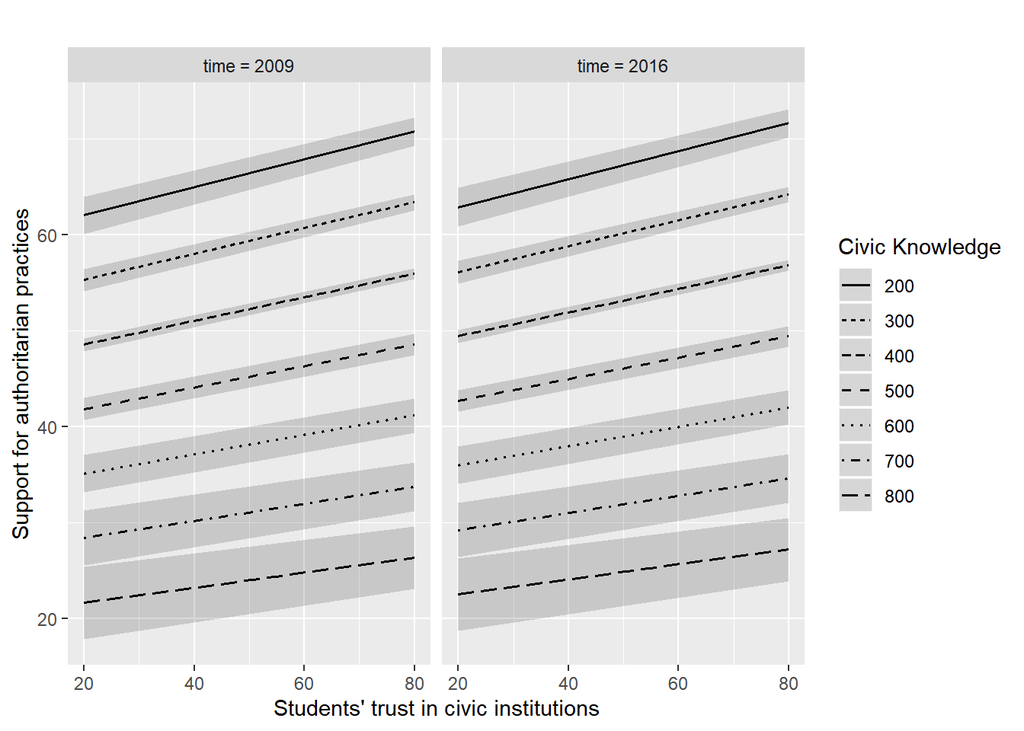

```r
plot2 <- plot_model(m3, type = "pred", terms = c("s_intrust[20,80]", "civic_knowledge[200, 300, 400, 500, 600, 700, 800]", "time"), colors = 'bw', axis.title = c("Students' trust in civic institutions", "Support for authoritarian practices"), title = c(""), legend.title = "Civic Knowledge")

plot2
```

# OLS by Mexico

```r
##########################################################3
#OLS
##########################################################3
#Borramos los modelos generados en el apartado anterior
rm(list=(ls()[!ls() %in% ("mergeiccs")]))

mex <- mergeiccs  %>% filter(idcountry == 484)

#VD: Support authoritarianism
m1 <- lm(l_autgov ~ s_intrust + civic_knowledge, data=mex, w=totwgts)
m2 <- lm(l_autgov ~ s_intrust + civic_knowledge + s_hisced + s_homelit + s_gender + s_poldisc + time, data=mex, w=totwgts)
m3 <- lm(l_autgov ~ s_intrust*civic_knowledge + s_hisced + s_homelit + s_gender + s_poldisc + time, data=mex, w=totwgts)

#VD: Trust
m4 <- lm(s_intrust ~ civic_knowledge, data=mex, w=totwgts)
m5 <- lm(s_intrust ~ civic_knowledge + s_hisced + s_homelit + s_gender + s_poldisc + time, data=mex, w=totwgts)

#Table
#print(xtable(iccs_count[, c(2:1,6,3:5)],  caption = "Sample", format="text"), include.rownames=FALSE)
#texreg(list(m1, m2, m3, m4, m5), digits = 2)
#htmlreg(list(m1, m2, m3, m4, m5), digits = 4)
htmlreg(list(m1, m2, m3),  caption = "VD: Support authoritarianism")
```

<!DOCTYPE HTML PUBLIC “-//W3C//DTD HTML 4.01 Transitional//EN” “http://www.w3.org/TR/html4/loose.dtd”>

VD: Support authoritarianism

|  | **Model 1** | **Model 2** | **Model 3** |  |
| --- | --- | --- | --- | --- |
| (Intercept) | 77.58*** | -267.31*** | -276.62*** |  |
|  | (0.71) | (50.95) | (50.97) |  |
| s_intrust | 0.20*** | 0.19*** | 0.39*** |  |
|  | (0.01) | (0.01) | (0.05) |  |
| civic_knowledge | -0.08*** | -0.08*** | -0.06*** |  |
|  | (0.00) | (0.00) | (0.01) |  |
| s_hisced |  | 0.03 | 0.03 |  |
|  |  | (0.06) | (0.06) |  |
| s_homelit |  | -0.21** | -0.22** |  |
|  |  | (0.08) | (0.08) |  |
| s_gender |  | -1.05*** | -1.05*** |  |
|  |  | (0.17) | (0.17) |  |
| s_poldisc |  | -0.02* | -0.02* |  |
|  |  | (0.01) | (0.01) |  |
| time |  | 0.17*** | 0.17*** |  |
|  |  | (0.03) | (0.03) |  |
| s_intrust:civic_knowledge |  |  | -0.00*** |  |
|  |  |  | (0.00) |  |
| R<sup>2</sup> | 0.40 | 0.41 | 0.41 |  |
| Adj. R<sup>2</sup> | 0.40 | 0.41 | 0.41 |  |
| Num. obs. | 11583 | 11379 | 11379 |  |
| RMSE | 166.24 | 165.07 | 164.96 |  |
| p < 0.001, p < 0.01, p < 0.05 |  |  |  |  |

```r
htmlreg(list(m4, m5),  caption = "VD: Institutional Trusts")
```

<!DOCTYPE HTML PUBLIC “-//W3C//DTD HTML 4.01 Transitional//EN” “http://www.w3.org/TR/html4/loose.dtd”>

VD: Institutional Trusts

|  | **Model 1** | **Model 2** |  |
| --- | --- | --- | --- |
| (Intercept) | 63.18*** | -272.13*** |  |
|  | (0.57) | (58.97) |  |
| civic_knowledge | -0.03*** | -0.03*** |  |
|  | (0.00) | (0.00) |  |
| s_hisced |  | -0.04 |  |
|  |  | (0.07) |  |
| s_homelit |  | -0.34*** |  |
|  |  | (0.09) |  |
| s_gender |  | -0.74*** |  |
|  |  | (0.20) |  |
| s_poldisc |  | 0.10*** |  |
|  |  | (0.01) |  |
| time |  | 0.16*** |  |
|  |  | (0.03) |  |
| R<sup>2</sup> | 0.05 | 0.06 |  |
| Adj. R<sup>2</sup> | 0.05 | 0.06 |  |
| Num. obs. | 11634 | 11426 |  |
| RMSE | 193.85 | 191.71 |  |
| p < 0.001, p < 0.01, p < 0.05 |  |  |  |

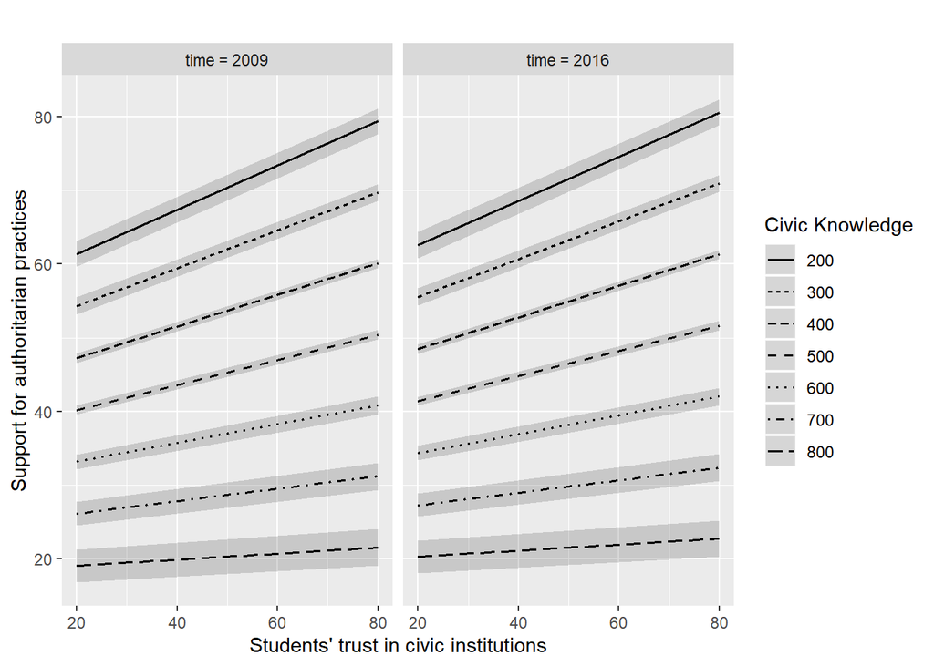

```r
plot2 <- plot_model(m3, type = "pred", terms = c("s_intrust[20,80]", "civic_knowledge[200, 300, 400, 500, 600, 700, 800]", "time"), colors = 'bw', axis.title = c("Students' trust in civic institutions", "Support for authoritarian practices"), title = c(""), legend.title = "Civic Knowledge")

plot2
```

# OLS by Guatemala 2009

```r
##########################################################3
#OLS
##########################################################3
#Borramos los modelos generados en el apartado anterior
rm(list=(ls()[!ls() %in% ("mergeiccs")]))

gtm <- mergeiccs  %>% filter(idcountry == 320)

#VD: Support authoritarianism
m1 <- lm(l_autgov ~ s_intrust + civic_knowledge, data=gtm, w=totwgts)
m2 <- lm(l_autgov ~ s_intrust + civic_knowledge + s_hisced + s_homelit + s_gender + s_poldisc + time, data=gtm, w=totwgts)
m3 <- lm(l_autgov ~ s_intrust*civic_knowledge + s_hisced + s_homelit + s_gender + s_poldisc + time, data=gtm, w=totwgts)

#VD: Trust
m4 <- lm(s_intrust ~ civic_knowledge, data=gtm, w=totwgts)
m5 <- lm(s_intrust ~ civic_knowledge + s_hisced + s_homelit + s_gender + s_poldisc + time, data=gtm, w=totwgts)

#Table
#print(xtable(iccs_count[, c(2:1,6,3:5)],  caption = "Sample", format="text"), include.rownames=FALSE)
#texreg(list(m1, m2, m3, m4, m5), digits = 2)
#htmlreg(list(m1, m2, m3, m4, m5), digits = 4)
htmlreg(list(m1, m2, m3),  caption = "VD: Support authoritarianism")
```

<!DOCTYPE HTML PUBLIC “-//W3C//DTD HTML 4.01 Transitional//EN” “http://www.w3.org/TR/html4/loose.dtd”>

VD: Support authoritarianism

|  | **Model 1** | **Model 2** | **Model 3** |  |
| --- | --- | --- | --- | --- |
| (Intercept) | 74.49*** | 75.83*** | 89.85*** |  |
|  | (1.11) | (1.32) | (3.62) |  |
| s_intrust | 0.11*** | 0.11*** | -0.19* |  |
|  | (0.01) | (0.01) | (0.07) |  |
| civic_knowledge | -0.07*** | -0.07*** | -0.10*** |  |
|  | (0.00) | (0.00) | (0.01) |  |
| s_hisced |  | 0.23** | 0.26*** |  |
|  |  | (0.08) | (0.08) |  |
| s_homelit |  | -0.13 | -0.13 |  |
|  |  | (0.11) | (0.11) |  |
| s_gender |  | -1.34*** | -1.36*** |  |
|  |  | (0.24) | (0.24) |  |
| s_poldisc |  | -0.00 | 0.00 |  |
|  |  | (0.01) | (0.01) |  |
| s_intrust:civic_knowledge |  |  | 0.00*** |  |
|  |  |  | (0.00) |  |
| R<sup>2</sup> | 0.35 | 0.36 | 0.36 |  |
| Adj. R<sup>2</sup> | 0.35 | 0.36 | 0.36 |  |
| Num. obs. | 3798 | 3684 | 3684 |  |
| RMSE | 41.28 | 41.24 | 41.15 |  |
| p < 0.001, p < 0.01, p < 0.05 |  |  |  |  |

```r
htmlreg(list(m4, m5),  caption = "VD: Institutional Trusts")
```

<!DOCTYPE HTML PUBLIC “-//W3C//DTD HTML 4.01 Transitional//EN” “http://www.w3.org/TR/html4/loose.dtd”>

VD: Institutional Trusts

|  | **Model 1** | **Model 2** |  |
| --- | --- | --- | --- |
| (Intercept) | 65.52*** | 58.11*** |  |
|  | (0.93) | (1.35) |  |
| civic_knowledge | -0.04*** | -0.04*** |  |
|  | (0.00) | (0.00) |  |
| s_hisced |  | -0.17 |  |
|  |  | (0.10) |  |
| s_homelit |  | -0.26 |  |
|  |  | (0.14) |  |
| s_gender |  | -0.74* |  |
|  |  | (0.30) |  |
| s_poldisc |  | 0.12*** |  |
|  |  | (0.02) |  |
| R<sup>2</sup> | 0.10 | 0.12 |  |
| Adj. R<sup>2</sup> | 0.10 | 0.12 |  |
| Num. obs. | 3804 | 3690 |  |
| RMSE | 52.42 | 51.66 |  |
| p < 0.001, p < 0.01, p < 0.05 |  |  |  |

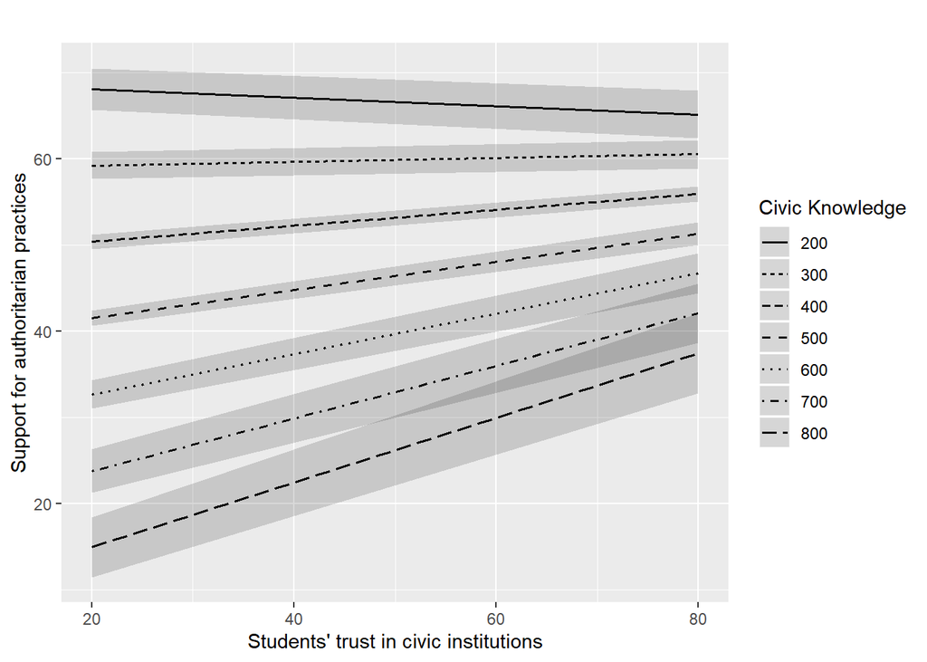

```r
plot2 <- plot_model(m3, type = "pred", terms = c("s_intrust[20,80]", "civic_knowledge[200, 300, 400, 500, 600, 700, 800]", "time"), colors = 'bw', axis.title = c("Students' trust in civic institutions", "Support for authoritarian practices"), title = c(""), legend.title = "Civic Knowledge")
plot2
```

# OLS by Paraguay 2009

```r
##########################################################3
#OLS
##########################################################3
#Borramos los modelos generados en el apartado anterior
rm(list=(ls()[!ls() %in% ("mergeiccs")]))

pry <- mergeiccs  %>% filter(idcountry == 604)

#VD: Support authoritarianism
m1 <- lm(l_autgov ~ s_intrust + civic_knowledge, data=pry, w=totwgts)
m2 <- lm(l_autgov ~ s_intrust + civic_knowledge + s_hisced + s_homelit + s_gender + s_poldisc + time, data=pry, w=totwgts)
m3 <- lm(l_autgov ~ s_intrust*civic_knowledge + s_hisced + s_homelit + s_gender + s_poldisc + time, data=pry, w=totwgts)

#VD: Trust
m4 <- lm(s_intrust ~ civic_knowledge, data=pry, w=totwgts)
m5 <- lm(s_intrust ~ civic_knowledge + s_hisced + s_homelit + s_gender + s_poldisc + time, data=pry, w=totwgts)

#Table
#print(xtable(iccs_count[, c(2:1,6,3:5)],  caption = "Sample", format="text"), include.rownames=FALSE)
#texreg(list(m1, m2, m3, m4, m5), digits = 2)
#htmlreg(list(m1, m2, m3, m4, m5), digits = 4)
htmlreg(list(m1, m2, m3),  caption = "VD: Support authoritarianism")
```

<!DOCTYPE HTML PUBLIC “-//W3C//DTD HTML 4.01 Transitional//EN” “http://www.w3.org/TR/html4/loose.dtd”>

VD: Support authoritarianism

|  | **Model 1** | **Model 2** | **Model 3** |  |
| --- | --- | --- | --- | --- |
| (Intercept) | 69.95*** | 71.15*** | 71.25*** |  |
|  | (0.84) | (1.02) | (2.71) |  |
| s_intrust | 0.10*** | 0.09*** | 0.09 |  |
|  | (0.01) | (0.01) | (0.05) |  |
| civic_knowledge | -0.05*** | -0.06*** | -0.06*** |  |
|  | (0.00) | (0.00) | (0.01) |  |
| s_hisced |  | 0.35*** | 0.35*** |  |
|  |  | (0.08) | (0.08) |  |
| s_homelit |  | -0.04 | -0.04 |  |
|  |  | (0.10) | (0.10) |  |
| s_gender |  | -1.67*** | -1.67*** |  |
|  |  | (0.20) | (0.20) |  |
| s_poldisc |  | -0.00 | -0.00 |  |
|  |  | (0.01) | (0.01) |  |
| s_intrust:civic_knowledge |  |  | 0.00 |  |
|  |  |  | (0.00) |  |
| R<sup>2</sup> | 0.35 | 0.36 | 0.36 |  |
| Adj. R<sup>2</sup> | 0.35 | 0.36 | 0.36 |  |
| Num. obs. | 5034 | 4914 | 4914 |  |
| RMSE | 69.71 | 69.44 | 69.45 |  |
| p < 0.001, p < 0.01, p < 0.05 |  |  |  |  |

```r
htmlreg(list(m4, m5),  caption = "VD: Institutional Trusts")
```

<!DOCTYPE HTML PUBLIC “-//W3C//DTD HTML 4.01 Transitional//EN” “http://www.w3.org/TR/html4/loose.dtd”>

VD: Institutional Trusts

|  | **Model 1** | **Model 2** |  |
| --- | --- | --- | --- |
| (Intercept) | 63.12*** | 55.90*** |  |
|  | (0.68) | (1.08) |  |
| civic_knowledge | -0.03*** | -0.03*** |  |
|  | (0.00) | (0.00) |  |
| s_hisced |  | 0.15 |  |
|  |  | (0.11) |  |
| s_homelit |  | 0.19 |  |
|  |  | (0.14) |  |
| s_gender |  | -1.75*** |  |
|  |  | (0.27) |  |
| s_poldisc |  | 0.14*** |  |
|  |  | (0.01) |  |
| R<sup>2</sup> | 0.09 | 0.12 |  |
| Adj. R<sup>2</sup> | 0.09 | 0.11 |  |
| Num. obs. | 5037 | 4916 |  |
| RMSE | 92.75 | 91.50 |  |
| p < 0.001, p < 0.01, p < 0.05 |  |  |  |

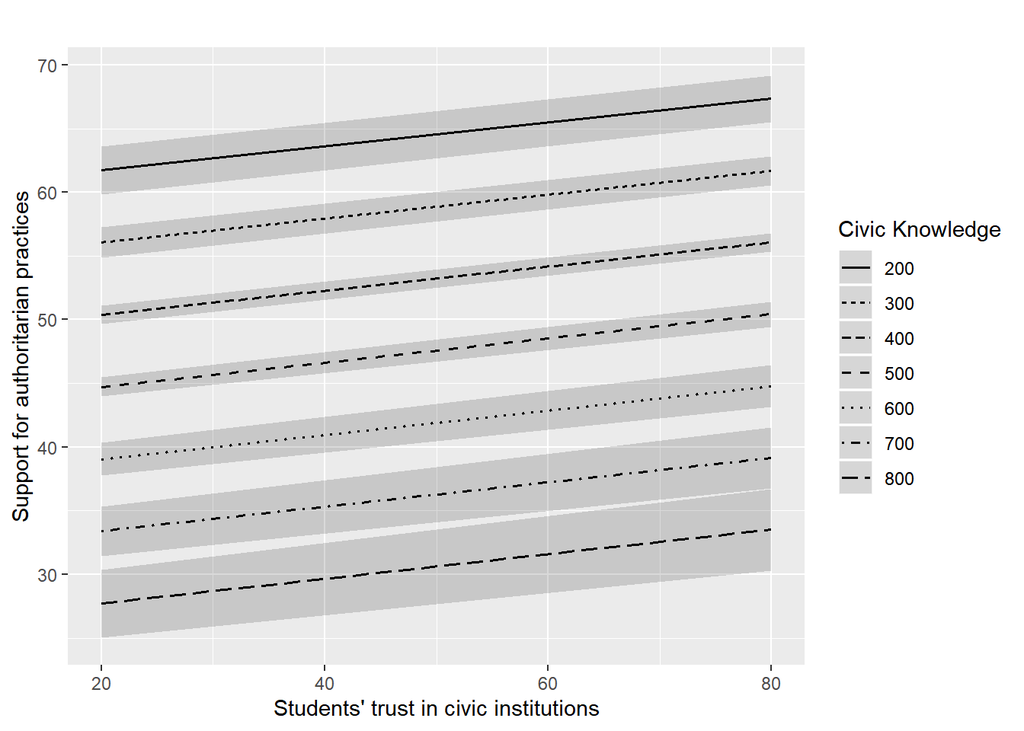

```r
plot2 <- plot_model(m3, type = "pred", terms = c("s_intrust[20,80]", "civic_knowledge[200, 300, 400, 500, 600, 700, 800]", "time"), colors = 'bw', axis.title = c("Students' trust in civic institutions", "Support for authoritarian practices"), title = c(""), legend.title = "Civic Knowledge")
plot2
```

# OLS by Peru 2016

```r
##########################################################3
#OLS
##########################################################3
#Borramos los modelos generados en el apartado anterior
rm(list=(ls()[!ls() %in% ("mergeiccs")]))

per <- mergeiccs  %>% filter(idcountry == 600)

#VD: Support authoritarianism
m1 <- lm(l_autgov ~ s_intrust + civic_knowledge, data=per, w=totwgts)
m2 <- lm(l_autgov ~ s_intrust + civic_knowledge + s_hisced + s_homelit + s_gender + s_poldisc + time, data=per, w=totwgts)
m3 <- lm(l_autgov ~ s_intrust*civic_knowledge + s_hisced + s_homelit + s_gender + s_poldisc + time, data=per, w=totwgts)

#VD: Trust
m4 <- lm(s_intrust ~ civic_knowledge, data=per, w=totwgts)
m5 <- lm(s_intrust ~ civic_knowledge + s_hisced + s_homelit + s_gender + s_poldisc + time, data=per, w=totwgts)

#Table
#print(xtable(iccs_count[, c(2:1,6,3:5)],  caption = "Sample", format="text"), include.rownames=FALSE)
#texreg(list(m1, m2, m3, m4, m5), digits = 2)
#htmlreg(list(m1, m2, m3, m4, m5), digits = 4)
htmlreg(list(m1, m2, m3),  caption = "VD: Support authoritarianism")
```

<!DOCTYPE HTML PUBLIC “-//W3C//DTD HTML 4.01 Transitional//EN” “http://www.w3.org/TR/html4/loose.dtd”>

VD: Support authoritarianism

|  | **Model 1** | **Model 2** | **Model 3** |  |
| --- | --- | --- | --- | --- |
| (Intercept) | 70.30*** | 71.54*** | 76.89*** |  |
|  | (1.19) | (1.40) | (4.16) |  |
| s_intrust | 0.13*** | 0.10*** | -0.01 |  |
|  | (0.01) | (0.02) | (0.08) |  |
| civic_knowledge | -0.06*** | -0.06*** | -0.07*** |  |
|  | (0.00) | (0.00) | (0.01) |  |
| s_hisced |  | 0.15 | 0.15 |  |
|  |  | (0.10) | (0.10) |  |
| s_homelit |  | -0.02 | -0.01 |  |
|  |  | (0.14) | (0.14) |  |
| s_gender |  | -1.40*** | -1.41*** |  |
|  |  | (0.28) | (0.28) |  |
| s_poldisc |  | 0.01 | 0.01 |  |
|  |  | (0.01) | (0.01) |  |
| s_intrust:civic_knowledge |  |  | 0.00 |  |
|  |  |  | (0.00) |  |
| R<sup>2</sup> | 0.36 | 0.36 | 0.36 |  |
| Adj. R<sup>2</sup> | 0.35 | 0.36 | 0.36 |  |
| Num. obs. | 2958 | 2756 | 2756 |  |
| RMSE | 36.43 | 36.54 | 36.54 |  |
| p < 0.001, p < 0.01, p < 0.05 |  |  |  |  |

```r
htmlreg(list(m4, m5),  caption = "VD: Institutional Trusts")
```

<!DOCTYPE HTML PUBLIC “-//W3C//DTD HTML 4.01 Transitional//EN” “http://www.w3.org/TR/html4/loose.dtd”>

VD: Institutional Trusts

|  | **Model 1** | **Model 2** |  |
| --- | --- | --- | --- |
| (Intercept) | 63.22*** | 59.21*** |  |
|  | (0.92) | (1.28) |  |
| civic_knowledge | -0.03*** | -0.03*** |  |
|  | (0.00) | (0.00) |  |
| s_hisced |  | 0.05 |  |
|  |  | (0.12) |  |
| s_homelit |  | 0.23 |  |
|  |  | (0.17) |  |
| s_gender |  | -2.32*** |  |
|  |  | (0.34) |  |
| s_poldisc |  | 0.10*** |  |
|  |  | (0.02) |  |
| R<sup>2</sup> | 0.07 | 0.10 |  |
| Adj. R<sup>2</sup> | 0.07 | 0.10 |  |
| Num. obs. | 2968 | 2766 |  |
| RMSE | 45.62 | 44.53 |  |
| p < 0.001, p < 0.01, p < 0.05 |  |  |  |

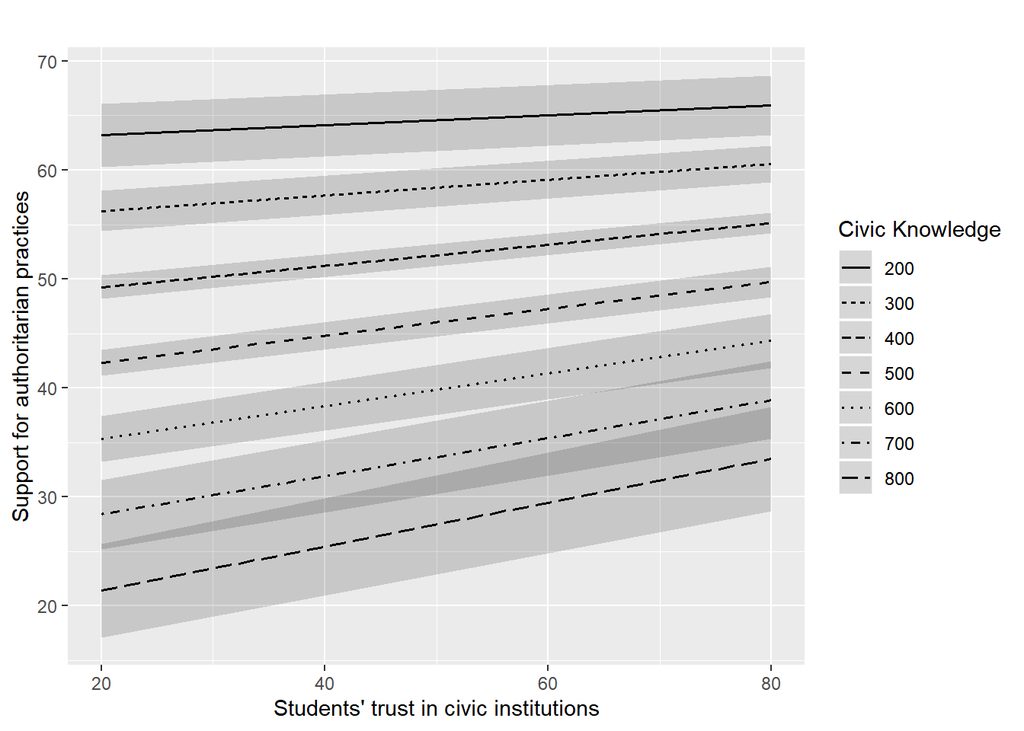

```r
plot2 <- plot_model(m3, type = "pred", terms = c("s_intrust[20,80]", "civic_knowledge[200, 300, 400, 500, 600, 700, 800]", "time"), colors = 'bw', axis.title = c("Students' trust in civic institutions", "Support for authoritarian practices"), title = c(""), legend.title = "Civic Knowledge")
plot2
```